# Project: Tmdb movies analysis

- Introduction
- Data Wrangling
- Exploratory Data Analysis
- Conclusions

## Introduction

### Dataset Description

> data set contains information about 10,000 movies collected from The Movie Database (TMDb), including user ratings and revenue (adjusted for inflation)

### Question(s) for Analysis

> **1)** Which genres are most popular from year to year?  
> **2)** What kinds of properties are associated with movies that have high revenues?

```python
# Importing important packages

import numpy as np
import pandas as pd
import matplotlib.pyplot as plt
import seaborn as sns
%matplotlib inline
```

```python
# Upgrade pandas to use dataframe.explode() function.
!pip install --upgrade pandas
```

## Data Wrangling

### General Properties

```python
# Load data and printing the firist 5 lines
df = pd.read_csv('tmdb-movies.csv')
df.head()
```

|  | id | imdb_id | popularity | budget | revenue | original_title | cast | homepage | director | tagline | ... | overview | runtime | genres | production_companies | release_date | vote_count | vote_average | release_year | budget_adj | revenue_adj |
| --- | --- | --- | --- | --- | --- | --- | --- | --- | --- | --- | --- | --- | --- | --- | --- | --- | --- | --- | --- | --- | --- |
| 0 | 135397 | tt0369610 | 32.985763 | 150000000 | 1513528810 | Jurassic World | Chris Pratt\|Bryce Dallas Howard\|Irrfan Khan\|Vi... | http://www.jurassicworld.com/ | Colin Trevorrow | The park is open. | ... | Twenty-two years after the events of Jurassic ... | 124 | Action\|Adventure\|Science Fiction\|Thriller | Universal Studios\|Amblin Entertainment\|Legenda... | 6/9/15 | 5562 | 6.5 | 2015 | 1.379999e+08 | 1.392446e+09 |
| 1 | 76341 | tt1392190 | 28.419936 | 150000000 | 378436354 | Mad Max: Fury Road | Tom Hardy\|Charlize Theron\|Hugh Keays-Byrne\|Nic... | http://www.madmaxmovie.com/ | George Miller | What a Lovely Day. | ... | An apocalyptic story set in the furthest reach... | 120 | Action\|Adventure\|Science Fiction\|Thriller | Village Roadshow Pictures\|Kennedy Miller Produ... | 5/13/15 | 6185 | 7.1 | 2015 | 1.379999e+08 | 3.481613e+08 |
| 2 | 262500 | tt2908446 | 13.112507 | 110000000 | 295238201 | Insurgent | Shailene Woodley\|Theo James\|Kate Winslet\|Ansel... | http://www.thedivergentseries.movie/#insurgent | Robert Schwentke | One Choice Can Destroy You | ... | Beatrice Prior must confront her inner demons ... | 119 | Adventure\|Science Fiction\|Thriller | Summit Entertainment\|Mandeville Films\|Red Wago... | 3/18/15 | 2480 | 6.3 | 2015 | 1.012000e+08 | 2.716190e+08 |
| 3 | 140607 | tt2488496 | 11.173104 | 200000000 | 2068178225 | Star Wars: The Force Awakens | Harrison Ford\|Mark Hamill\|Carrie Fisher\|Adam D... | http://www.starwars.com/films/star-wars-episod... | J.J. Abrams | Every generation has a story. | ... | Thirty years after defeating the Galactic Empi... | 136 | Action\|Adventure\|Science Fiction\|Fantasy | Lucasfilm\|Truenorth Productions\|Bad Robot | 12/15/15 | 5292 | 7.5 | 2015 | 1.839999e+08 | 1.902723e+09 |
| 4 | 168259 | tt2820852 | 9.335014 | 190000000 | 1506249360 | Furious 7 | Vin Diesel\|Paul Walker\|Jason Statham\|Michelle ... | http://www.furious7.com/ | James Wan | Vengeance Hits Home | ... | Deckard Shaw seeks revenge against Dominic Tor... | 137 | Action\|Crime\|Thriller | Universal Pictures\|Original Film\|Media Rights ... | 4/1/15 | 2947 | 7.3 | 2015 | 1.747999e+08 | 1.385749e+09 |

5 rows × 21 columns

```python
# print dataframe shape
print(f'Dataframe shape: {df.shape}')
```

```
Dataframe shape: (10866, 21)
```

```python
# print the number of missing values for each columns
df.isna().sum()
```

```
id                         0
imdb_id                   10
popularity                 0
budget                     0
revenue                    0
original_title             0
cast                      76
homepage                7930
director                  44
tagline                 2824
keywords                1493
overview                   4
runtime                    0
genres                    23
production_companies    1030
release_date               0
vote_count                 0
vote_average               0
release_year               0
budget_adj                 0
revenue_adj                0
dtype: int64
```

```python
# print the number of duplicated rows
print(f'The number of duplicated rows: {df.duplicated().sum()}')

# print the duplicated rows of the dataframe
df[df.duplicated()]
```

```
The number of duplicated rows: 1
```

|  | id | imdb_id | popularity | budget | revenue | original_title | cast | homepage | director | tagline | ... | overview | runtime | genres | production_companies | release_date | vote_count | vote_average | release_year | budget_adj | revenue_adj |
| --- | --- | --- | --- | --- | --- | --- | --- | --- | --- | --- | --- | --- | --- | --- | --- | --- | --- | --- | --- | --- | --- |
| 2090 | 42194 | tt0411951 | 0.59643 | 30000000 | 967000 | TEKKEN | Jon Foo\|Kelly Overton\|Cary-Hiroyuki Tagawa\|Ian... | NaN | Dwight H. Little | Survival is no game | ... | In the year of 2039, after World Wars destroy ... | 92 | Crime\|Drama\|Action\|Thriller\|Science Fiction | Namco\|Light Song Films | 3/20/10 | 110 | 5.0 | 2010 | 30000000.0 | 967000.0 |

1 rows × 21 columns

```python
# print columns names
df.columns
```

```
Index(['id', 'imdb_id', 'popularity', 'budget', 'revenue', 'original_title',
       'cast', 'homepage', 'director', 'tagline', 'keywords', 'overview',
       'runtime', 'genres', 'production_companies', 'release_date',
       'vote_count', 'vote_average', 'release_year', 'budget_adj',
       'revenue_adj'],
      dtype='object')
```

```python
df.describe()
```

|  | id | popularity | budget | revenue | runtime | vote_count | vote_average | release_year | budget_adj | revenue_adj |
| --- | --- | --- | --- | --- | --- | --- | --- | --- | --- | --- |
| count | 10866.000000 | 10866.000000 | 1.086600e+04 | 1.086600e+04 | 10866.000000 | 10866.000000 | 10866.000000 | 10866.000000 | 1.086600e+04 | 1.086600e+04 |
| mean | 66064.177434 | 0.646441 | 1.462570e+07 | 3.982332e+07 | 102.070863 | 217.389748 | 5.974922 | 2001.322658 | 1.755104e+07 | 5.136436e+07 |
| std | 92130.136561 | 1.000185 | 3.091321e+07 | 1.170035e+08 | 31.381405 | 575.619058 | 0.935142 | 12.812941 | 3.430616e+07 | 1.446325e+08 |
| min | 5.000000 | 0.000065 | 0.000000e+00 | 0.000000e+00 | 0.000000 | 10.000000 | 1.500000 | 1960.000000 | 0.000000e+00 | 0.000000e+00 |
| 25% | 10596.250000 | 0.207583 | 0.000000e+00 | 0.000000e+00 | 90.000000 | 17.000000 | 5.400000 | 1995.000000 | 0.000000e+00 | 0.000000e+00 |
| 50% | 20669.000000 | 0.383856 | 0.000000e+00 | 0.000000e+00 | 99.000000 | 38.000000 | 6.000000 | 2006.000000 | 0.000000e+00 | 0.000000e+00 |
| 75% | 75610.000000 | 0.713817 | 1.500000e+07 | 2.400000e+07 | 111.000000 | 145.750000 | 6.600000 | 2011.000000 | 2.085325e+07 | 3.369710e+07 |
| max | 417859.000000 | 32.985763 | 4.250000e+08 | 2.781506e+09 | 900.000000 | 9767.000000 | 9.200000 | 2015.000000 | 4.250000e+08 | 2.827124e+09 |

```python
df.info()
```

```
<class 'pandas.core.frame.DataFrame'>
RangeIndex: 10866 entries, 0 to 10865
Data columns (total 21 columns):
 #   Column                Non-Null Count  Dtype
---  ------                --------------  -----
 0   id                    10866 non-null  int64
 1   imdb_id               10856 non-null  object
 2   popularity            10866 non-null  float64
 3   budget                10866 non-null  int64
 4   revenue               10866 non-null  int64
 5   original_title        10866 non-null  object
 6   cast                  10790 non-null  object
 7   homepage              2936 non-null   object
 8   director              10822 non-null  object
 9   tagline               8042 non-null   object
 10  keywords              9373 non-null   object
 11  overview              10862 non-null  object
 12  runtime               10866 non-null  int64
 13  genres                10843 non-null  object
 14  production_companies  9836 non-null   object
 15  release_date          10866 non-null  object
 16  vote_count            10866 non-null  int64
 17  vote_average          10866 non-null  float64
 18  release_year          10866 non-null  int64
 19  budget_adj            10866 non-null  float64
 20  revenue_adj           10866 non-null  float64
dtypes: float64(4), int64(6), object(11)
memory usage: 1.7+ MB
```

```python
# get the number of missing values for each column
df.isna().sum()
```

```
id                         0
imdb_id                   10
popularity                 0
budget                     0
revenue                    0
original_title             0
cast                      76
homepage                7930
director                  44
tagline                 2824
keywords                1493
overview                   4
runtime                    0
genres                    23
production_companies    1030
release_date               0
vote_count                 0
vote_average               0
release_year               0
budget_adj                 0
revenue_adj                0
dtype: int64
```

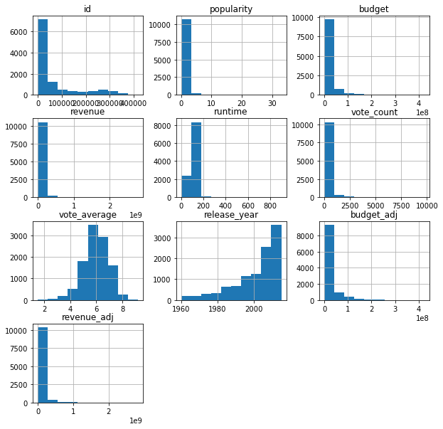

```python
# get the distribution of each column of the data
df.hist(figsize = (10, 10));
```

```python
# how many rows have badget less than 6000

df[df['budget_adj'] < 6000].shape
```

```
(5759, 21)
```

```python
# how many rows have revenue less than 30

df[df['revenue_adj'] < 30].shape
```

```
(6040, 21)
```

```python
# how many rows have popularity less than 1

df[df['popularity'] < 1].shape
```

```
(9110, 21)
```

```python
# how many rows have vote count less than 145

df[df['vote_count'] < 145].shape
```

```
(8139, 21)
```

## Obsevations from the dataset

> 1) There are missing values in columns (imdb_id, cast, homepage, director, tagline, keywords, overview, generes, production_campanies)  
> 2) There is a row that is duplicated.  
> 3) Some movies in the database have zero budget or zero revenue or zero runtime, that is there value has not been recorded  
> 4) more than 50% of the values of budget and renenue columns have values less than 10  
> 5) more than 80% of the values of popularity column have values less than 1  
> 6) 75% of the values of vote couts column have values less than or equal to 145  
> 7) vote_count is different for all the movies from 10 to 9767, so we cannot directly conculed the popularity of the movies based on the average vote count but we can make weighted votes based on vote count and vote average

## Data Cleaning

> 1) Remove some columns with missing values and the columns we wont use.  
> 2) Remove duplicated rows.  
> 3) Remove rows with values less than 30 in budget and the revenue columns  
> 4) Remove nan values  
> 5) Get The most popular genere from the whole dataset

### Remove some columns with missing values and the columns we wont use

```python
# After discussing the structure of the data and any problems that need to be
# cleaned, perform those cleaning steps in the second part of this section.
df.drop(['imdb_id', 'popularity', 'homepage', 'director', 'tagline', 'keywords', 'overview', 'runtime', 'release_date', 'production_companies', 'vote_count', 'cast'], axis = 1, inplace = True)
df.head()
```

|  | id | budget | revenue | original_title | genres | vote_average | release_year | budget_adj | revenue_adj |
| --- | --- | --- | --- | --- | --- | --- | --- | --- | --- |
| 0 | 135397 | 150000000 | 1513528810 | Jurassic World | Action\|Adventure\|Science Fiction\|Thriller | 6.5 | 2015 | 1.379999e+08 | 1.392446e+09 |
| 1 | 76341 | 150000000 | 378436354 | Mad Max: Fury Road | Action\|Adventure\|Science Fiction\|Thriller | 7.1 | 2015 | 1.379999e+08 | 3.481613e+08 |
| 2 | 262500 | 110000000 | 295238201 | Insurgent | Adventure\|Science Fiction\|Thriller | 6.3 | 2015 | 1.012000e+08 | 2.716190e+08 |
| 3 | 140607 | 200000000 | 2068178225 | Star Wars: The Force Awakens | Action\|Adventure\|Science Fiction\|Fantasy | 7.5 | 2015 | 1.839999e+08 | 1.902723e+09 |
| 4 | 168259 | 190000000 | 1506249360 | Furious 7 | Action\|Crime\|Thriller | 7.3 | 2015 | 1.747999e+08 | 1.385749e+09 |

```
<class 'pandas.core.frame.DataFrame'>
RangeIndex: 10866 entries, 0 to 10865
Data columns (total 9 columns):
 #   Column          Non-Null Count  Dtype
---  ------          --------------  -----
 0   id              10866 non-null  int64
 1   budget          10866 non-null  int64
 2   revenue         10866 non-null  int64
 3   original_title  10866 non-null  object
 4   genres          10843 non-null  object
 5   vote_average    10866 non-null  float64
 6   release_year    10866 non-null  int64
 7   budget_adj      10866 non-null  float64
 8   revenue_adj     10866 non-null  float64
dtypes: float64(3), int64(4), object(2)
memory usage: 764.1+ KB
```

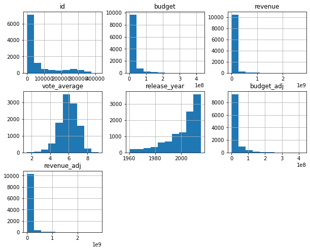

```python
df.info()
df.hist(figsize=(10,8));
```

### Remove duplicated rows.

```python
# Removing all duplicated rows
df.drop_duplicates(keep ='first', inplace=True)

print(f'The shape of the data after removing the duplicates rows: {df.shape}')
```

```
The shape of the data after removing the duplicates rows: (10865, 9)
```

### Remove rows with values less than 30 in budget and the revenue columns

```python
# this will replace all the value from '0' to NAN in the list
df[['budget_adj', 'revenue_adj']] = df[['budget_adj', 'revenue_adj']].replace(range(30), np.NAN)

# Removing all the row which has NaN values from ['budget', 'revenue']
df.dropna(subset = ['budget_adj', 'revenue_adj'], inplace = True)

print(f'The shape of the data after removing the inefficient rows: {df.shape}')
```

```
The shape of the data after removing the inefficient rows: (3853, 9)
```

```python
df.info()
```

```
<class 'pandas.core.frame.DataFrame'>
Int64Index: 3853 entries, 0 to 10848
Data columns (total 9 columns):
 #   Column          Non-Null Count  Dtype
---  ------          --------------  -----
 0   id              3853 non-null   int64
 1   budget          3853 non-null   int64
 2   revenue         3853 non-null   int64
 3   original_title  3853 non-null   object
 4   genres          3853 non-null   object
 5   vote_average    3853 non-null   float64
 6   release_year    3853 non-null   int64
 7   budget_adj      3853 non-null   float64
 8   revenue_adj     3853 non-null   float64
dtypes: float64(3), int64(4), object(2)
memory usage: 301.0+ KB
```

### Remove nan values

```python
# drop all nan values from the whole dataset
df.dropna(inplace = True)

df.info()
```

```
<class 'pandas.core.frame.DataFrame'>
Int64Index: 3853 entries, 0 to 10848
Data columns (total 9 columns):
 #   Column          Non-Null Count  Dtype
---  ------          --------------  -----
 0   id              3853 non-null   int64
 1   budget          3853 non-null   int64
 2   revenue         3853 non-null   int64
 3   original_title  3853 non-null   object
 4   genres          3853 non-null   object
 5   vote_average    3853 non-null   float64
 6   release_year    3853 non-null   int64
 7   budget_adj      3853 non-null   float64
 8   revenue_adj     3853 non-null   float64
dtypes: float64(3), int64(4), object(2)
memory usage: 301.0+ KB
```

```python
df.head()
```

|  | id | budget | revenue | original_title | genres | vote_average | release_year | budget_adj | revenue_adj |
| --- | --- | --- | --- | --- | --- | --- | --- | --- | --- |
| 0 | 135397 | 150000000 | 1513528810 | Jurassic World | Action\|Adventure\|Science Fiction\|Thriller | 6.5 | 2015 | 1.379999e+08 | 1.392446e+09 |
| 1 | 76341 | 150000000 | 378436354 | Mad Max: Fury Road | Action\|Adventure\|Science Fiction\|Thriller | 7.1 | 2015 | 1.379999e+08 | 3.481613e+08 |
| 2 | 262500 | 110000000 | 295238201 | Insurgent | Adventure\|Science Fiction\|Thriller | 6.3 | 2015 | 1.012000e+08 | 2.716190e+08 |
| 3 | 140607 | 200000000 | 2068178225 | Star Wars: The Force Awakens | Action\|Adventure\|Science Fiction\|Fantasy | 7.5 | 2015 | 1.839999e+08 | 1.902723e+09 |
| 4 | 168259 | 190000000 | 1506249360 | Furious 7 | Action\|Crime\|Thriller | 7.3 | 2015 | 1.747999e+08 | 1.385749e+09 |

## Exploratory Data Analysis

### Research Question 1 : Which genres are most popular from year to year?

### Get The movies genere number from the whole dataset

```python
generes = df['genres'].str.split('|').apply(pd.Series).stack().reset_index(drop=True)
generes_counts = generes.value_counts()
generes_counts
```

```
Drama              1755
Comedy             1357
Thriller           1204
Action             1085
Adventure           749
Romance             667
Crime               651
Science Fiction     519
Horror              463
Family              425
Fantasy             396
Mystery             344
Animation           201
Music               136
History             129
War                 119
Western              52
Documentary          35
Foreign              13
TV Movie              1
dtype: int64
```

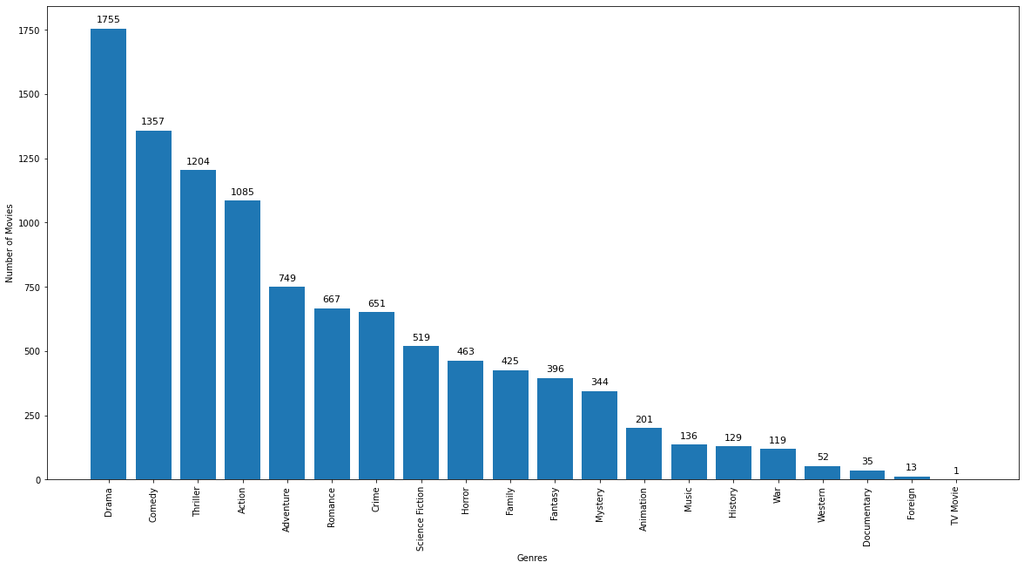

```python
plt.figure(figsize=(20, 10))
graph = plt.bar(generes_counts.index, generes_counts)
plt.xticks(rotation = 'vertical')
plt.xlabel('Genres')
plt.ylabel('Number of Movies')

# Place the values above the bars.
for p in graph.patches:
    plt.annotate(p.get_height(), (p.get_x() + p.get_width() / 2, p.get_height()), ha = 'center', va = 'center', fontsize = 11, xytext = (0, 10), textcoords = 'offset points')

plt.show()
```

### Add profit column to the dataframe = revenue - budget

```python
df['newGenres'] = df.genres.str.split("|")
```

```python
df['profit'] = df['revenue'] - df['budget']
df.head()
```

|  | id | budget | revenue | original_title | genres | vote_average | release_year | budget_adj | revenue_adj | newGenres | profit |
| --- | --- | --- | --- | --- | --- | --- | --- | --- | --- | --- | --- |
| 0 | 135397 | 150000000 | 1513528810 | Jurassic World | Action\|Adventure\|Science Fiction\|Thriller | 6.5 | 2015 | 1.379999e+08 | 1.392446e+09 | [Action, Adventure, Science Fiction, Thriller] | 1363528810 |
| 1 | 76341 | 150000000 | 378436354 | Mad Max: Fury Road | Action\|Adventure\|Science Fiction\|Thriller | 7.1 | 2015 | 1.379999e+08 | 3.481613e+08 | [Action, Adventure, Science Fiction, Thriller] | 228436354 |
| 2 | 262500 | 110000000 | 295238201 | Insurgent | Adventure\|Science Fiction\|Thriller | 6.3 | 2015 | 1.012000e+08 | 2.716190e+08 | [Adventure, Science Fiction, Thriller] | 185238201 |
| 3 | 140607 | 200000000 | 2068178225 | Star Wars: The Force Awakens | Action\|Adventure\|Science Fiction\|Fantasy | 7.5 | 2015 | 1.839999e+08 | 1.902723e+09 | [Action, Adventure, Science Fiction, Fantasy] | 1868178225 |
| 4 | 168259 | 190000000 | 1506249360 | Furious 7 | Action\|Crime\|Thriller | 7.3 | 2015 | 1.747999e+08 | 1.385749e+09 | [Action, Crime, Thriller] | 1316249360 |

### Create vote average mean dataframe for each year per genere

### To get the most popular genere from 1960 to 2015 as per vote average

```python
vote_average_mean = df.explode("newGenres").pivot_table(index="release_year", columns="newGenres", values='vote_average', aggfunc="mean", fill_value=0)
vote_average_mean
```

| newGenres release_year | Action | Adventure | Animation | Comedy | Crime | Documentary | Drama | Family | Fantasy | Foreign | History | Horror | Music | Mystery | Romance | Science Fiction | TV Movie | Thriller | War | Western |
| --- | --- | --- | --- | --- | --- | --- | --- | --- | --- | --- | --- | --- | --- | --- | --- | --- | --- | --- | --- | --- |
| 1960 | 6.950000 | 7.000000 | 0.000000 | 7.550000 | 0.000000 | 0.000000 | 7.600000 | 0.000000 | 0.000000 | 0.000000 | 6.900000 | 8.000000 | 0.000000 | 0.000000 | 7.550000 | 0.000000 | 0.0 | 8.000000 | 0.000000 | 7.000000 |
| 1961 | 6.550000 | 6.800000 | 6.600000 | 6.900000 | 6.600000 | 0.000000 | 6.616667 | 7.050000 | 0.000000 | 0.000000 | 6.700000 | 6.300000 | 6.600000 | 0.000000 | 7.400000 | 0.000000 | 0.0 | 0.000000 | 7.000000 | 6.100000 |
| 1962 | 6.400000 | 6.766667 | 0.000000 | 0.000000 | 7.700000 | 0.000000 | 6.900000 | 0.000000 | 0.000000 | 0.000000 | 7.500000 | 0.000000 | 0.000000 | 0.000000 | 0.000000 | 0.000000 | 0.0 | 6.700000 | 7.500000 | 6.600000 |
| 1963 | 6.150000 | 7.100000 | 0.000000 | 7.500000 | 0.000000 | 0.000000 | 6.466667 | 0.000000 | 0.000000 | 0.000000 | 6.466667 | 7.000000 | 0.000000 | 7.500000 | 6.900000 | 0.000000 | 0.0 | 7.233333 | 7.500000 | 0.000000 |
| 1964 | 7.000000 | 7.000000 | 0.000000 | 7.266667 | 7.200000 | 0.000000 | 6.925000 | 7.150000 | 7.200000 | 0.000000 | 0.000000 | 0.000000 | 7.066667 | 7.200000 | 6.400000 | 0.000000 | 0.0 | 7.100000 | 7.700000 | 0.000000 |
| 1965 | 6.450000 | 6.450000 | 0.000000 | 6.600000 | 0.000000 | 0.000000 | 6.600000 | 7.200000 | 0.000000 | 0.000000 | 5.700000 | 0.000000 | 7.200000 | 0.000000 | 7.050000 | 0.000000 | 0.0 | 6.300000 | 6.900000 | 0.000000 |
| 1966 | 6.950000 | 6.850000 | 0.000000 | 0.000000 | 0.000000 | 0.000000 | 7.250000 | 0.000000 | 0.000000 | 0.000000 | 0.000000 | 0.000000 | 0.000000 | 6.300000 | 7.000000 | 6.700000 | 0.0 | 6.300000 | 7.000000 | 6.900000 |
| 1967 | 6.266667 | 6.180000 | 7.000000 | 6.160000 | 7.325000 | 0.000000 | 7.200000 | 6.050000 | 5.100000 | 0.000000 | 0.000000 | 0.000000 | 5.650000 | 7.000000 | 6.625000 | 0.000000 | 0.0 | 6.900000 | 7.200000 | 0.000000 |
| 1968 | 6.800000 | 7.266667 | 0.000000 | 0.000000 | 6.700000 | 0.000000 | 6.450000 | 6.200000 | 0.000000 | 0.000000 | 6.900000 | 7.300000 | 6.200000 | 7.400000 | 6.000000 | 6.966667 | 0.0 | 6.700000 | 6.250000 | 6.300000 |
| 1969 | 6.400000 | 6.800000 | 0.000000 | 0.000000 | 7.000000 | 0.000000 | 7.000000 | 0.000000 | 0.000000 | 0.000000 | 7.000000 | 0.000000 | 0.000000 | 0.000000 | 0.000000 | 0.000000 | 0.0 | 6.400000 | 0.000000 | 7.100000 |
| 1970 | 6.825000 | 6.550000 | 7.000000 | 7.000000 | 6.700000 | 0.000000 | 6.685714 | 7.000000 | 0.000000 | 0.000000 | 6.750000 | 0.000000 | 0.000000 | 6.300000 | 6.600000 | 5.900000 | 0.0 | 6.200000 | 6.766667 | 7.250000 |
| 1971 | 6.650000 | 6.200000 | 0.000000 | 0.000000 | 6.600000 | 0.000000 | 6.728571 | 7.200000 | 7.200000 | 0.000000 | 0.000000 | 0.000000 | 6.600000 | 6.450000 | 6.200000 | 6.550000 | 0.0 | 6.550000 | 0.000000 | 0.000000 |
| 1972 | 7.000000 | 7.350000 | 0.000000 | 6.400000 | 7.466667 | 0.000000 | 7.400000 | 0.000000 | 0.000000 | 0.000000 | 0.000000 | 0.000000 | 0.000000 | 6.900000 | 0.000000 | 6.100000 | 0.0 | 7.033333 | 0.000000 | 0.000000 |
| 1973 | 6.275000 | 6.100000 | 6.900000 | 7.033333 | 7.200000 | 0.000000 | 7.128571 | 6.900000 | 0.000000 | 0.000000 | 7.300000 | 7.200000 | 0.000000 | 0.000000 | 6.900000 | 6.100000 | 0.0 | 6.766667 | 0.000000 | 0.000000 |
| 1974 | 6.383333 | 6.100000 | 0.000000 | 7.250000 | 7.180000 | 0.000000 | 6.762500 | 0.000000 | 0.000000 | 0.000000 | 0.000000 | 6.800000 | 0.000000 | 7.450000 | 6.100000 | 7.500000 | 0.0 | 6.671429 | 0.000000 | 7.000000 |
| 1975 | 0.000000 | 7.450000 | 0.000000 | 7.100000 | 7.200000 | 0.000000 | 6.880000 | 0.000000 | 7.600000 | 0.000000 | 0.000000 | 7.200000 | 6.600000 | 0.000000 | 7.200000 | 7.100000 | 0.0 | 7.250000 | 7.200000 | 0.000000 |
| 1976 | 6.133333 | 5.900000 | 0.000000 | 6.633333 | 7.033333 | 0.000000 | 6.914286 | 6.600000 | 0.000000 | 0.000000 | 7.300000 | 6.533333 | 5.700000 | 6.950000 | 5.800000 | 5.900000 | 0.0 | 6.900000 | 0.000000 | 7.100000 |
| 1977 | 6.633333 | 6.385714 | 6.300000 | 6.900000 | 6.700000 | 0.000000 | 6.400000 | 6.250000 | 6.040000 | 0.000000 | 6.400000 | 5.680000 | 6.250000 | 5.800000 | 7.600000 | 6.600000 | 0.0 | 6.066667 | 6.400000 | 0.000000 |
| 1978 | 6.460000 | 6.440000 | 6.400000 | 6.450000 | 7.500000 | 0.000000 | 6.671429 | 6.100000 | 6.400000 | 0.000000 | 0.000000 | 6.520000 | 6.550000 | 6.350000 | 0.000000 | 6.433333 | 0.0 | 6.400000 | 7.000000 | 0.000000 |
| 1979 | 5.950000 | 6.160000 | 0.000000 | 6.700000 | 7.100000 | 0.000000 | 6.600000 | 6.300000 | 0.000000 | 0.000000 | 5.300000 | 6.850000 | 0.000000 | 6.000000 | 5.300000 | 6.283333 | 0.0 | 6.125000 | 7.800000 | 0.000000 |
| 1980 | 6.680000 | 6.700000 | 0.000000 | 6.580000 | 6.566667 | 0.000000 | 6.437500 | 0.000000 | 5.866667 | 0.000000 | 6.533333 | 6.720000 | 6.300000 | 6.366667 | 6.133333 | 6.420000 | 0.0 | 6.560000 | 0.000000 | 6.000000 |
| 1981 | 6.700000 | 6.716667 | 6.900000 | 6.122222 | 6.600000 | 0.000000 | 6.650000 | 6.566667 | 6.500000 | 0.000000 | 6.550000 | 6.375000 | 0.000000 | 6.366667 | 6.433333 | 6.320000 | 0.0 | 6.500000 | 0.000000 | 0.000000 |
| 1982 | 6.262500 | 6.566667 | 7.300000 | 6.316667 | 5.850000 | 0.000000 | 6.683333 | 6.500000 | 7.000000 | 0.000000 | 7.100000 | 6.280000 | 5.750000 | 6.100000 | 6.400000 | 6.542857 | 0.0 | 6.462500 | 6.850000 | 6.200000 |
| 1983 | 6.070000 | 6.071429 | 6.750000 | 5.940000 | 6.416667 | 0.000000 | 6.200000 | 7.400000 | 5.775000 | 5.300000 | 7.200000 | 5.757143 | 5.700000 | 6.150000 | 6.100000 | 6.180000 | 0.0 | 6.184615 | 0.000000 | 5.200000 |
| 1984 | 6.012500 | 6.136364 | 0.000000 | 5.912500 | 6.025000 | 8.400000 | 6.638462 | 6.666667 | 5.850000 | 0.000000 | 7.133333 | 5.557143 | 6.933333 | 6.100000 | 6.342857 | 6.090909 | 0.0 | 6.100000 | 6.150000 | 0.000000 |
| 1985 | 5.933333 | 6.147059 | 6.200000 | 6.494737 | 6.900000 | 0.000000 | 6.428571 | 6.583333 | 6.157143 | 0.000000 | 0.000000 | 6.271429 | 0.000000 | 7.100000 | 6.025000 | 6.457143 | 0.0 | 6.380000 | 5.600000 | 0.000000 |
| 1986 | 6.057143 | 6.330000 | 6.700000 | 5.887500 | 6.300000 | 0.000000 | 6.468421 | 6.400000 | 5.871429 | 0.000000 | 6.800000 | 5.742857 | 6.500000 | 6.600000 | 5.955556 | 5.990000 | 0.0 | 6.412500 | 6.900000 | 0.000000 |
| 1987 | 6.200000 | 5.900000 | 0.000000 | 6.343478 | 6.350000 | 0.000000 | 6.533333 | 6.440000 | 6.333333 | 0.000000 | 7.300000 | 6.480000 | 6.900000 | 6.600000 | 6.309091 | 6.250000 | 0.0 | 6.141667 | 7.350000 | 0.000000 |
| 1988 | 6.150000 | 6.171429 | 6.900000 | 6.004000 | 6.463636 | 7.200000 | 6.234783 | 6.266667 | 6.360000 | 5.500000 | 4.600000 | 5.777778 | 6.350000 | 6.400000 | 6.211111 | 5.787500 | 0.0 | 5.994737 | 5.150000 | 0.000000 |
| 1989 | 6.100000 | 6.153846 | 6.700000 | 6.345833 | 6.340000 | 0.000000 | 6.594737 | 6.437500 | 6.180000 | 0.000000 | 6.500000 | 5.785714 | 0.000000 | 6.300000 | 6.340000 | 6.225000 | 0.0 | 5.918750 | 6.633333 | 0.000000 |
| 1990 | 6.089474 | 6.327273 | 6.400000 | 6.183333 | 6.228571 | 7.600000 | 6.240909 | 6.520000 | 6.312500 | 0.000000 | 0.000000 | 6.007692 | 6.400000 | 6.280000 | 6.557143 | 5.963636 | 0.0 | 6.115000 | 0.000000 | 7.300000 |
| 1991 | 6.028571 | 6.150000 | 6.300000 | 6.059091 | 6.357143 | 0.000000 | 6.270000 | 6.300000 | 5.883333 | 0.000000 | 7.200000 | 5.450000 | 5.750000 | 6.350000 | 5.557143 | 6.000000 | 0.0 | 6.360000 | 6.200000 | 6.100000 |
| 1992 | 6.105882 | 6.077778 | 7.300000 | 6.264706 | 6.400000 | 0.000000 | 6.400000 | 6.200000 | 6.366667 | 6.300000 | 6.633333 | 5.875000 | 6.150000 | 6.500000 | 6.412500 | 5.533333 | 0.0 | 6.172727 | 5.100000 | 6.850000 |
| 1993 | 6.357143 | 6.050000 | 7.300000 | 5.956522 | 6.520000 | 0.000000 | 6.655556 | 5.930000 | 5.950000 | 4.000000 | 7.066667 | 5.355556 | 5.800000 | 6.288889 | 6.485714 | 5.716667 | 0.0 | 6.032000 | 7.100000 | 6.700000 |
| 1994 | 5.757143 | 5.640000 | 6.260000 | 6.051852 | 6.471429 | 7.300000 | 6.500000 | 5.900000 | 5.933333 | 0.000000 | 7.100000 | 5.720000 | 0.000000 | 6.060000 | 6.200000 | 5.330000 | 0.0 | 5.861905 | 6.400000 | 6.700000 |
| 1995 | 5.772414 | 5.800000 | 6.300000 | 6.120833 | 6.447059 | 0.000000 | 6.485714 | 5.955556 | 5.744444 | 0.000000 | 6.366667 | 5.216667 | 0.000000 | 6.242857 | 6.100000 | 5.590909 | 0.0 | 6.027586 | 6.950000 | 6.200000 |
| 1996 | 5.850000 | 5.761111 | 6.333333 | 5.959259 | 6.730769 | 0.000000 | 6.208511 | 6.042857 | 5.825000 | 0.000000 | 6.233333 | 5.800000 | 5.350000 | 6.262500 | 6.161111 | 5.675000 | 5.6 | 5.947059 | 6.500000 | 0.000000 |
| 1997 | 5.770968 | 5.700000 | 7.100000 | 6.148000 | 6.157895 | 6.900000 | 6.510256 | 5.950000 | 5.312500 | 0.000000 | 6.500000 | 5.627273 | 6.150000 | 6.531250 | 6.522222 | 5.872222 | 0.0 | 6.205000 | 6.900000 | 0.000000 |
| 1998 | 6.085714 | 6.122222 | 6.650000 | 6.202439 | 6.342857 | 0.000000 | 6.388889 | 6.100000 | 6.125000 | 0.000000 | 7.000000 | 5.490000 | 6.100000 | 6.141667 | 6.190476 | 5.878571 | 0.0 | 5.945833 | 6.766667 | 6.100000 |
| 1999 | 5.880000 | 6.033333 | 6.575000 | 6.048214 | 6.515000 | 0.000000 | 6.425455 | 5.944444 | 6.361538 | 0.000000 | 6.100000 | 5.680000 | 6.900000 | 6.066667 | 6.204545 | 5.725000 | 0.0 | 6.082857 | 6.133333 | 6.600000 |
| 2000 | 5.806897 | 6.042105 | 6.100000 | 5.769767 | 6.041176 | 0.000000 | 6.264444 | 5.875000 | 5.650000 | 6.400000 | 6.250000 | 5.677778 | 7.160000 | 5.800000 | 5.835294 | 5.400000 | 0.0 | 5.971875 | 6.200000 | 6.100000 |
| 2001 | 5.682051 | 5.855000 | 6.012500 | 5.809804 | 6.088889 | 0.000000 | 6.397917 | 6.133333 | 6.133333 | 0.000000 | 6.433333 | 5.420000 | 6.500000 | 6.147059 | 6.100000 | 5.700000 | 0.0 | 6.000000 | 6.675000 | 5.800000 |
| 2002 | 5.960976 | 5.944000 | 6.583333 | 5.865909 | 6.445455 | 6.866667 | 6.267188 | 6.042857 | 6.277778 | 6.500000 | 6.325000 | 5.725000 | 6.266667 | 6.080000 | 6.048276 | 6.068750 | 0.0 | 5.997917 | 6.480000 | 7.100000 |
| 2003 | 5.917949 | 6.134783 | 6.400000 | 5.728889 | 6.250000 | 6.700000 | 6.312500 | 6.093333 | 6.235714 | 0.000000 | 6.425000 | 5.372727 | 6.100000 | 5.850000 | 5.727778 | 5.692308 | 0.0 | 5.931579 | 6.433333 | 6.350000 |
| 2004 | 5.953659 | 6.064516 | 6.300000 | 5.864516 | 6.061905 | 6.600000 | 6.324194 | 5.987500 | 6.250000 | 0.000000 | 6.320000 | 5.664286 | 5.883333 | 6.038462 | 6.077419 | 6.166667 | 0.0 | 6.087179 | 6.320000 | 6.000000 |
| 2005 | 5.872500 | 5.887879 | 6.114286 | 5.979661 | 6.388000 | 6.900000 | 6.376829 | 5.955556 | 5.821053 | 0.000000 | 6.600000 | 5.279167 | 6.680000 | 6.264286 | 6.251613 | 5.846154 | 0.0 | 5.952174 | 6.433333 | 6.250000 |
| 2006 | 6.055263 | 5.993939 | 5.975000 | 5.878125 | 6.181481 | 6.500000 | 6.302247 | 5.742308 | 5.977778 | 0.000000 | 6.362500 | 5.493333 | 6.275000 | 5.973333 | 6.137931 | 6.069231 | 0.0 | 5.990385 | 6.533333 | 5.800000 |
| 2007 | 5.947500 | 6.083333 | 6.133333 | 6.025926 | 6.175000 | 6.300000 | 6.442667 | 6.200000 | 5.915000 | 6.200000 | 6.316667 | 5.757143 | 6.311111 | 6.300000 | 6.187097 | 6.038462 | 0.0 | 6.151852 | 5.966667 | 6.850000 |
| 2008 | 5.975000 | 5.947500 | 6.290909 | 5.771186 | 6.144444 | 4.500000 | 6.312346 | 5.950000 | 5.922222 | 6.833333 | 6.742857 | 5.377778 | 6.475000 | 6.153333 | 6.060606 | 5.823077 | 0.0 | 5.959615 | 6.844444 | 6.200000 |
| 2009 | 6.043902 | 5.979412 | 6.466667 | 5.921212 | 5.909091 | 6.900000 | 6.256627 | 6.108333 | 6.115789 | 0.000000 | 6.760000 | 5.715000 | 5.750000 | 5.709524 | 6.180556 | 5.883871 | 0.0 | 5.855556 | 6.733333 | 0.000000 |
| 2010 | 6.065385 | 6.267742 | 6.620000 | 5.885294 | 6.122222 | 7.125000 | 6.210843 | 6.059091 | 5.909524 | 6.300000 | 6.550000 | 5.568182 | 6.300000 | 6.187500 | 6.046875 | 6.156250 | 0.0 | 6.074074 | 6.500000 | 5.933333 |
| 2011 | 6.036207 | 6.112500 | 6.000000 | 5.952778 | 6.248000 | 6.525000 | 6.316854 | 6.087500 | 5.926316 | 0.000000 | 5.466667 | 5.593750 | 5.966667 | 6.181250 | 6.160606 | 6.052174 | 0.0 | 5.995238 | 6.425000 | 5.950000 |
| 2012 | 5.897561 | 6.204000 | 6.163636 | 5.918519 | 6.137500 | 5.600000 | 6.262121 | 6.141667 | 6.200000 | 0.000000 | 6.300000 | 5.294737 | 6.542857 | 5.757143 | 6.253846 | 6.104348 | 0.0 | 5.781818 | 6.220000 | 7.700000 |
| 2013 | 6.171429 | 6.342424 | 6.207143 | 6.193617 | 6.094118 | 0.000000 | 6.450000 | 6.094737 | 6.093750 | 0.000000 | 6.887500 | 5.750000 | 6.428571 | 6.257143 | 6.404762 | 6.470000 | 0.0 | 6.030189 | 6.450000 | 5.850000 |
| 2014 | 6.365909 | 6.441379 | 6.960000 | 6.304167 | 6.323529 | 0.000000 | 6.503797 | 6.535714 | 6.457143 | 0.000000 | 6.575000 | 5.533333 | 6.660000 | 6.566667 | 6.440000 | 6.426087 | 0.0 | 6.265854 | 6.855556 | 6.200000 |
| 2015 | 6.227027 | 6.352941 | 6.788889 | 6.192308 | 6.250000 | 0.000000 | 6.444444 | 6.415385 | 6.384615 | 0.000000 | 6.800000 | 5.476471 | 6.166667 | 6.246154 | 6.450000 | 6.422727 | 0.0 | 6.014894 | 6.680000 | 7.300000 |

```python
vote_average_mean.idxmax(axis = 1)
```

```
release_year
1960             Horror
1961            Romance
1962              Crime
1963             Comedy
1964                War
1965             Family
1966              Drama
1967              Crime
1968            Mystery
1969            Western
1970            Western
1971             Family
1972              Crime
1973            History
```

[output cut: 43 more lines]

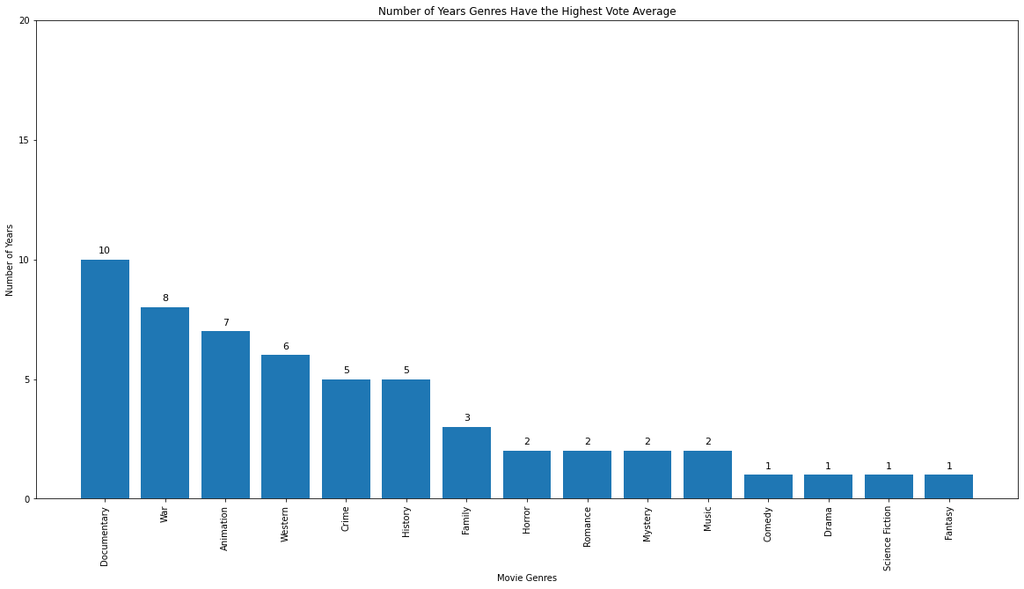

```python
vote_average_max = vote_average_mean.idxmax(axis = 1).value_counts()

plt.figure(figsize=(20, 10))
graph = plt.bar(vote_average_max.index, vote_average_max)

plt.title('Number of Years Genres Have the Highest Vote Average')
plt.xticks(rotation = 'vertical')
plt.yticks([0, 5, 10, 15, 20])
plt.xlabel('Movie Genres')
plt.ylabel('Number of Years')

# Place the values above the bars.
for p in graph.patches:
    plt.annotate(p.get_height(), (p.get_x() + p.get_width() / 2, p.get_height()), ha = 'center', va = 'center', fontsize = 11, xytext = (0, 10), textcoords = 'offset points')
plt.show()
```

This means that Documentary genre is the highest vote average genre over the years

### Create budget mean dataframe for each year per genere

### To get the most popular genere from 1960 to 2015 as per budget

```python
budget_mean = df.explode("newGenres").pivot_table(index="release_year", columns="newGenres", values='budget_adj', aggfunc="mean", fill_value=0)
budget_mean
```

| newGenres release_year | Action | Adventure | Animation | Comedy | Crime | Documentary | Drama | Family | Fantasy | Foreign | History | Horror | Music | Mystery | Romance | Science Fiction | TV Movie | Thriller | War | Western |
| --- | --- | --- | --- | --- | --- | --- | --- | --- | --- | --- | --- | --- | --- | --- | --- | --- | --- | --- | --- | --- |
| 1960 | 5.161077e+07 | 1.474593e+07 | 0.000000e+00 | 2.211890e+07 | 0.000000e+00 | 0.000000e+00 | 3.884804e+07 | 0.000000e+00 | 0.000000e+00 | 0.000000e+00 | 8.847561e+07 | 5.949601e+06 | 0.000000e+00 | 0.000000e+00 | 2.211890e+07 | 0.000000e+00 | 0.000000e+00 | 5.949601e+06 | 0.000000e+00 | 1.474593e+07 |
| 1961 | 4.376917e+07 | 3.647431e+07 | 2.917944e+07 | 2.261407e+07 | 4.376917e+07 | 0.000000e+00 | 3.092656e+07 | 2.553201e+07 | 0.000000e+00 | 0.000000e+00 | 2.188458e+07 | 1.458972e+06 | 4.376917e+07 | 0.000000e+00 | 1.823715e+07 | 0.000000e+00 | 0.000000e+00 | 0.000000e+00 | 4.376917e+07 | 4.376917e+07 |
| 1962 | 5.802801e+07 | 7.472759e+07 | 0.000000e+00 | 0.000000e+00 | 1.441690e+07 | 0.000000e+00 | 5.067540e+07 | 0.000000e+00 | 0.000000e+00 | 0.000000e+00 | 1.081267e+08 | 0.000000e+00 | 0.000000e+00 | 0.000000e+00 | 0.000000e+00 | 0.000000e+00 | 0.000000e+00 | 7.929294e+06 | 1.081267e+08 | 6.559688e+07 |
| 1963 | 6.942175e+07 | 2.314058e+07 | 0.000000e+00 | 2.848072e+07 | 0.000000e+00 | 0.000000e+00 | 1.236894e+08 | 0.000000e+00 | 0.000000e+00 | 0.000000e+00 | 1.236894e+08 | 1.780045e+07 | 0.000000e+00 | 2.848072e+07 | 1.250125e+08 | 0.000000e+00 | 0.000000e+00 | 2.492063e+07 | 2.848072e+07 | 0.000000e+00 |
| 1964 | 2.460594e+07 | 2.460594e+07 | 0.000000e+00 | 1.945041e+07 | 1.501075e+07 | 0.000000e+00 | 4.206765e+07 | 8.084808e+07 | 4.218160e+07 | 0.000000e+00 | 0.000000e+00 | 0.000000e+00 | 5.507043e+07 | 1.501075e+07 | 7.030267e+07 | 0.000000e+00 | 0.000000e+00 | 1.980834e+07 | 1.265448e+07 | 0.000000e+00 |
| 1965 | 5.744068e+07 | 5.744068e+07 | 0.000000e+00 | 3.875516e+07 | 0.000000e+00 | 0.000000e+00 | 9.734926e+07 | 5.674862e+07 | 0.000000e+00 | 0.000000e+00 | 1.384113e+08 | 0.000000e+00 | 5.674862e+07 | 0.000000e+00 | 7.681826e+07 | 0.000000e+00 | 0.000000e+00 | 7.612620e+07 | 9.688789e+07 | 0.000000e+00 |
| 1966 | 5.593755e+07 | 5.748941e+07 | 0.000000e+00 | 0.000000e+00 | 0.000000e+00 | 0.000000e+00 | 6.550064e+07 | 0.000000e+00 | 0.000000e+00 | 0.000000e+00 | 0.000000e+00 | 0.000000e+00 | 0.000000e+00 | 2.015404e+07 | 8.061618e+07 | 3.436265e+07 | 0.000000e+00 | 2.015404e+07 | 8.061618e+07 | 3.125892e+07 |
| 1967 | 1.013198e+08 | 8.955366e+07 | 2.614705e+07 | 5.294779e+07 | 1.879320e+07 | 0.000000e+00 | 2.194485e+07 | 7.190440e+07 | 1.176617e+08 | 0.000000e+00 | 0.000000e+00 | 0.000000e+00 | 7.517278e+07 | 1.307353e+07 | 2.532996e+07 | 0.000000e+00 | 0.000000e+00 | 3.377328e+07 | 1.634191e+08 | 0.000000e+00 |
| 1968 | 4.137516e+07 | 5.328619e+07 | 0.000000e+00 | 0.000000e+00 | 3.447930e+07 | 0.000000e+00 | 3.588982e+07 | 6.268964e+07 | 0.000000e+00 | 0.000000e+00 | 4.827102e+07 | 2.006068e+07 | 6.268964e+07 | 4.388275e+07 | 5.955515e+06 | 3.918102e+07 | 0.000000e+00 | 3.447930e+07 | 4.607688e+07 | 1.128413e+07 |
| 1969 | 4.160985e+07 | 3.936318e+07 | 0.000000e+00 | 0.000000e+00 | 3.566559e+07 | 0.000000e+00 | 2.853247e+07 | 0.000000e+00 | 0.000000e+00 | 0.000000e+00 | 3.566559e+07 | 0.000000e+00 | 0.000000e+00 | 0.000000e+00 | 0.000000e+00 | 0.000000e+00 | 0.000000e+00 | 4.160985e+07 | 0.000000e+00 | 3.639104e+07 |
| 1970 | 7.610452e+07 | 5.965285e+07 | 2.246547e+07 | 4.068154e+07 | 5.616368e+07 | 0.000000e+00 | 6.032381e+07 | 2.246547e+07 | 0.000000e+00 | 0.000000e+00 | 1.052648e+08 | 0.000000e+00 | 0.000000e+00 | 3.650639e+07 | 3.594476e+07 | 1.684911e+07 | 0.000000e+00 | 5.616368e+07 | 7.672895e+07 | 5.256063e+07 |
| 1971 | 1.866868e+07 | 3.015709e+07 | 0.000000e+00 | 0.000000e+00 | 1.370532e+07 | 0.000000e+00 | 1.346453e+07 | 1.615558e+07 | 1.615558e+07 | 0.000000e+00 | 0.000000e+00 | 0.000000e+00 | 4.846675e+07 | 8.015863e+06 | 2.618551e+07 | 1.706703e+07 | 0.000000e+00 | 1.481063e+07 | 0.000000e+00 | 0.000000e+00 |
| 1972 | 1.764652e+07 | 1.825096e+07 | 0.000000e+00 | 5.245848e+06 | 2.233962e+07 | 0.000000e+00 | 1.998915e+07 | 0.000000e+00 | 0.000000e+00 | 0.000000e+00 | 0.000000e+00 | 0.000000e+00 | 0.000000e+00 | 1.825096e+07 | 0.000000e+00 | 9.386210e+06 | 0.000000e+00 | 1.538687e+07 | 0.000000e+00 | 0.000000e+00 |
| 1973 | 1.295318e+07 | 3.437812e+07 | 7.366739e+07 | 1.354989e+07 | 1.870333e+07 | 0.000000e+00 | 2.159297e+07 | 7.366739e+07 | 0.000000e+00 | 0.000000e+00 | 1.473348e+07 | 3.928928e+07 | 0.000000e+00 | 0.000000e+00 | 9.822319e+06 | 9.085645e+06 | 0.000000e+00 | 2.594729e+07 | 0.000000e+00 | 0.000000e+00 |
| 1974 | 2.727075e+07 | 2.211142e+07 | 0.000000e+00 | 1.194017e+07 | 2.352655e+07 | 0.000000e+00 | 2.382505e+07 | 0.000000e+00 | 0.000000e+00 | 0.000000e+00 | 0.000000e+00 | 3.758941e+05 | 0.000000e+00 | 1.680468e+07 | 2.874485e+07 | 1.238239e+07 | 0.000000e+00 | 2.532389e+07 | 0.000000e+00 | 1.149794e+07 |
| 1975 | 0.000000e+00 | 1.499174e+07 | 0.000000e+00 | 8.914007e+06 | 7.293278e+06 | 0.000000e+00 | 1.904356e+07 | 0.000000e+00 | 1.620728e+06 | 0.000000e+00 | 0.000000e+00 | 1.661247e+07 | 1.256065e+07 | 0.000000e+00 | 4.457003e+07 | 4.862185e+06 | 0.000000e+00 | 1.782801e+07 | 4.457003e+07 | 0.000000e+00 |
| 1976 | 5.364377e+07 | 6.322302e+07 | 0.000000e+00 | 5.492101e+07 | 1.570996e+07 | 0.000000e+00 | 2.649345e+07 | 1.341094e+08 | 0.000000e+00 | 0.000000e+00 | 3.256943e+07 | 3.652885e+07 | 2.299019e+07 | 2.777981e+07 | 2.873774e+07 | 6.322302e+07 | 0.000000e+00 | 1.954166e+07 | 0.000000e+00 | 1.417728e+07 |
| 1977 | 3.717707e+07 | 3.273981e+07 | 4.317337e+06 | 1.331179e+07 | 1.978780e+07 | 0.000000e+00 | 2.711128e+07 | 8.454785e+06 | 1.432636e+07 | 0.000000e+00 | 7.915118e+07 | 1.492360e+07 | 1.241234e+07 | 2.914203e+06 | 1.439112e+07 | 2.171261e+07 | 0.000000e+00 | 3.736296e+07 | 7.915118e+07 | 0.000000e+00 |
| 1978 | 5.268097e+07 | 5.950007e+07 | 8.356752e+06 | 2.456885e+07 | 7.688212e+06 | 0.000000e+00 | 1.962643e+07 | 8.022482e+07 | 1.320367e+08 | 0.000000e+00 | 0.000000e+00 | 2.089188e+07 | 5.014051e+07 | 1.908682e+07 | 0.000000e+00 | 9.192427e+07 | 0.000000e+00 | 2.380003e+07 | 3.342701e+07 | 0.000000e+00 |
| 1979 | 5.728683e+07 | 5.534388e+07 | 0.000000e+00 | 4.136269e+07 | 2.403643e+07 | 0.000000e+00 | 3.790030e+07 | 3.410169e+07 | 0.000000e+00 | 0.000000e+00 | 5.257970e+07 | 1.697573e+07 | 0.000000e+00 | 1.051594e+08 | 5.257970e+07 | 5.042643e+07 | 0.000000e+00 | 4.461763e+07 | 9.464345e+07 | 0.000000e+00 |
| 1980 | 7.991031e+07 | 6.747394e+07 | 0.000000e+00 | 2.884180e+07 | 3.439848e+07 | 0.000000e+00 | 3.588687e+07 | 0.000000e+00 | 7.849909e+07 | 0.000000e+00 | 5.203872e+07 | 1.484427e+07 | 6.218186e+07 | 1.984528e+07 | 2.205031e+07 | 6.562171e+07 | 0.000000e+00 | 2.450230e+07 | 0.000000e+00 | 7.144299e+07 |
| 1981 | 2.757919e+07 | 3.197588e+07 | 2.877829e+07 | 2.033133e+07 | 1.199095e+07 | 0.000000e+00 | 3.042705e+07 | 2.558070e+07 | 3.037708e+07 | 0.000000e+00 | 4.496608e+07 | 7.179584e+06 | 0.000000e+00 | 1.818628e+07 | 1.742685e+07 | 1.587602e+07 | 0.000000e+00 | 1.987834e+07 | 0.000000e+00 | 0.000000e+00 |
| 1982 | 2.443238e+07 | 3.483615e+07 | 1.581750e+07 | 3.679451e+07 | 1.129823e+06 | 0.000000e+00 | 3.534457e+07 | 4.558829e+07 | 2.734167e+07 | 0.000000e+00 | 4.971213e+07 | 1.590788e+07 | 7.140470e+07 | 1.412277e+07 | 2.517242e+07 | 3.163499e+07 | 0.000000e+00 | 2.485607e+07 | 2.372625e+07 | 7.908748e+06 |
| 1983 | 5.272958e+07 | 5.468589e+07 | 4.597555e+06 | 4.698264e+07 | 3.429922e+07 | 0.000000e+00 | 3.532090e+07 | 6.567936e+06 | 3.787510e+07 | 1.313587e+07 | 5.911142e+07 | 1.810154e+07 | 2.773129e+07 | 1.662618e+07 | 2.525007e+07 | 3.557676e+07 | 0.000000e+00 | 3.518477e+07 | 0.000000e+00 | 1.094656e+07 |
| 1984 | 3.810417e+07 | 4.075004e+07 | 0.000000e+00 | 2.381101e+07 | 5.378795e+07 | 2.518850e+06 | 3.275264e+07 | 4.561918e+07 | 3.169553e+07 | 0.000000e+00 | 2.826710e+07 | 7.301668e+06 | 3.746790e+07 | 2.099042e+07 | 3.595359e+07 | 3.628480e+07 | 0.000000e+00 | 2.184316e+07 | 1.778938e+07 | 0.000000e+00 |
| 1985 | 3.431241e+07 | 4.210728e+07 | 5.067915e+07 | 2.433667e+07 | 2.736674e+07 | 0.000000e+00 | 2.760792e+07 | 4.865199e+07 | 5.151898e+07 | 0.000000e+00 | 0.000000e+00 | 7.471555e+06 | 0.000000e+00 | 3.040749e+07 | 3.273873e+07 | 3.929966e+07 | 0.000000e+00 | 2.750867e+07 | 4.704039e+07 | 0.000000e+00 |
| 1986 | 2.674332e+07 | 4.028550e+07 | 2.785169e+07 | 3.199214e+07 | 1.668259e+07 | 0.000000e+00 | 2.127619e+07 | 2.586234e+07 | 3.597984e+07 | 0.000000e+00 | 4.874046e+07 | 1.881410e+07 | 2.884639e+07 | 1.923093e+07 | 1.872255e+07 | 2.858777e+07 | 0.000000e+00 | 2.685699e+07 | 2.088877e+07 | 0.000000e+00 |
| 1987 | 3.838161e+07 | 3.733982e+07 | 0.000000e+00 | 2.175486e+07 | 3.108910e+07 | 0.000000e+00 | 2.692043e+07 | 1.496883e+07 | 1.976653e+07 | 0.000000e+00 | 4.605793e+07 | 1.302096e+07 | 1.199425e+07 | 2.507598e+07 | 2.070513e+07 | 3.303217e+07 | 0.000000e+00 | 3.502322e+07 | 2.878621e+07 | 0.000000e+00 |
| 1988 | 3.187297e+07 | 4.209340e+07 | 7.587612e+07 | 3.121339e+07 | 3.483278e+07 | 4.609728e+06 | 2.587861e+07 | 3.666270e+07 | 4.056560e+07 | 2.765837e+07 | 2.950226e+07 | 1.116578e+07 | 1.152432e+07 | 3.687782e+07 | 3.400955e+07 | 1.959134e+07 | 0.000000e+00 | 2.150559e+07 | 7.283370e+07 | 0.000000e+00 |
| 1989 | 5.272540e+07 | 5.217399e+07 | 4.731669e+07 | 3.283029e+07 | 2.948836e+07 | 0.000000e+00 | 2.650931e+07 | 4.195179e+07 | 4.355247e+07 | 0.000000e+00 | 3.957716e+07 | 1.570522e+07 | 0.000000e+00 | 2.378654e+07 | 3.289302e+07 | 4.892177e+07 | 0.000000e+00 | 3.292600e+07 | 3.195489e+07 | 0.000000e+00 |
| 1990 | 4.598255e+07 | 5.726310e+07 | 6.330299e+07 | 3.986813e+07 | 4.248908e+07 | 8.344493e+05 | 3.906740e+07 | 4.720680e+07 | 4.024778e+07 | 0.000000e+00 | 0.000000e+00 | 2.332607e+07 | 1.835788e+07 | 3.971979e+07 | 3.385480e+07 | 3.967427e+07 | 0.000000e+00 | 3.846811e+07 | 0.000000e+00 | 3.671577e+07 |
| 1991 | 5.169243e+07 | 5.510428e+07 | 3.442350e+07 | 3.966344e+07 | 3.613895e+07 | 0.000000e+00 | 3.714535e+07 | 4.785489e+07 | 4.963388e+07 | 0.000000e+00 | 6.404371e+07 | 1.921311e+07 | 3.482377e+07 | 7.765300e+07 | 3.362295e+07 | 6.324317e+07 | 0.000000e+00 | 4.463046e+07 | 4.162841e+07 | 4.162841e+07 |
| 1992 | 4.444692e+07 | 5.300949e+07 | 4.351268e+07 | 3.455419e+07 | 3.067710e+07 | 0.000000e+00 | 3.625513e+07 | 4.144065e+07 | 7.666520e+07 | 1.554024e+07 | 6.267898e+07 | 2.602991e+07 | 4.351268e+07 | 3.554830e+07 | 4.209571e+07 | 5.905292e+07 | 0.000000e+00 | 3.113880e+07 | 7.770121e+06 | 5.749890e+07 |
| 1993 | 4.323553e+07 | 5.541911e+07 | 1.811364e+07 | 3.589257e+07 | 3.008877e+07 | 0.000000e+00 | 3.140056e+07 | 4.135948e+07 | 4.719610e+07 | 3.773675e+07 | 4.125885e+07 | 1.302933e+07 | 5.735986e+07 | 4.130674e+07 | 2.518658e+07 | 4.100727e+07 | 0.000000e+00 | 3.491619e+07 | 3.547254e+07 | 4.528410e+07 |
| 1994 | 5.694603e+07 | 4.058797e+07 | 4.648713e+07 | 3.281162e+07 | 4.028744e+07 | 1.029778e+06 | 4.746086e+07 | 4.790593e+07 | 3.542927e+07 | 0.000000e+00 | 2.648001e+07 | 3.577743e+07 | 0.000000e+00 | 4.972357e+07 | 5.479891e+07 | 4.847313e+07 | 0.000000e+00 | 5.148890e+07 | 5.148890e+07 | 6.840669e+07 |
| 1995 | 6.819297e+07 | 6.986485e+07 | 5.389975e+07 | 2.976709e+07 | 4.671007e+07 | 0.000000e+00 | 3.929262e+07 | 4.626793e+07 | 5.135581e+07 | 0.000000e+00 | 7.918017e+07 | 1.764859e+07 | 0.000000e+00 | 4.834624e+07 | 3.601267e+07 | 6.016565e+07 | 0.000000e+00 | 4.319148e+07 | 7.655673e+07 | 4.579094e+07 |
| 1996 | 6.858403e+07 | 6.924283e+07 | 1.010224e+08 | 4.163957e+07 | 3.855178e+07 | 0.000000e+00 | 4.426397e+07 | 7.815600e+07 | 6.371827e+07 | 0.000000e+00 | 2.825015e+07 | 2.950349e+07 | 4.726737e+07 | 5.908421e+07 | 2.886244e+07 | 5.630378e+07 | 6.951084e+06 | 5.738733e+07 | 5.074291e+07 | 0.000000e+00 |
| 1997 | 8.347958e+07 | 9.475261e+07 | 7.697942e+07 | 4.238595e+07 | 6.416938e+07 | 2.716921e+07 | 5.158794e+07 | 5.654591e+07 | 7.386628e+07 | 0.000000e+00 | 6.158353e+07 | 5.310345e+07 | 3.871612e+07 | 5.554829e+07 | 7.671527e+07 | 8.148875e+07 | 0.000000e+00 | 7.632000e+07 | 9.509222e+07 | 0.000000e+00 |
| 1998 | 8.204532e+07 | 8.943981e+07 | 1.137041e+08 | 4.338864e+07 | 4.948518e+07 | 0.000000e+00 | 5.227595e+07 | 1.004944e+08 | 8.561251e+07 | 0.000000e+00 | 5.919302e+07 | 4.041178e+07 | 4.314068e+07 | 5.451778e+07 | 4.790224e+07 | 8.169497e+07 | 0.000000e+00 | 7.056678e+07 | 8.784200e+07 | 1.270811e+08 |
| 1999 | 8.503607e+07 | 1.086514e+08 | 8.672475e+07 | 4.516817e+07 | 5.283337e+07 | 0.000000e+00 | 5.282147e+07 | 6.094368e+07 | 9.848105e+07 | 0.000000e+00 | 7.854317e+07 | 5.245157e+07 | 1.047242e+08 | 6.087278e+07 | 3.546046e+07 | 7.324151e+07 | 0.000000e+00 | 5.771053e+07 | 4.799860e+07 | 4.974401e+07 |
| 2000 | 7.761934e+07 | 8.590792e+07 | 9.922303e+07 | 5.251578e+07 | 4.295710e+07 | 0.000000e+00 | 4.835547e+07 | 9.776830e+07 | 8.800730e+07 | 2.785843e+07 | 1.076348e+08 | 3.911436e+07 | 3.185991e+07 | 4.389813e+07 | 4.886398e+07 | 8.149494e+07 | 0.000000e+00 | 6.068705e+07 | 9.792659e+07 | 6.964607e+07 |
| 2001 | 7.313145e+07 | 9.266024e+07 | 9.497852e+07 | 4.056908e+07 | 5.856410e+07 | 0.000000e+00 | 4.429840e+07 | 7.512078e+07 | 9.554295e+07 | 0.000000e+00 | 1.186334e+08 | 3.848400e+07 | 5.028576e+07 | 3.411946e+07 | 5.018433e+07 | 8.922691e+07 | 0.000000e+00 | 5.831570e+07 | 1.052922e+08 | 4.310208e+07 |
| 2002 | 7.079902e+07 | 8.277321e+07 | 1.008197e+08 | 4.696136e+07 | 5.033640e+07 | 2.844773e+06 | 3.909165e+07 | 6.199851e+07 | 9.401761e+07 | 4.849046e+06 | 1.181955e+08 | 3.894390e+07 | 2.747792e+07 | 5.867345e+07 | 2.850905e+07 | 8.500983e+07 | 0.000000e+00 | 5.225352e+07 | 8.000925e+07 | 9.698091e+07 |
| 2003 | 8.480609e+07 | 1.027649e+08 | 6.993581e+07 | 4.779029e+07 | 4.885628e+07 | 1.540958e+07 | 4.113915e+07 | 6.148029e+07 | 8.805477e+07 | 0.000000e+00 | 8.564173e+07 | 2.732777e+07 | 2.192902e+07 | 4.006492e+07 | 3.309846e+07 | 1.102378e+08 | 0.000000e+00 | 6.930570e+07 | 1.051013e+08 | 4.267270e+07 |
| 2004 | 7.321577e+07 | 1.001947e+08 | 9.158600e+07 | 4.474944e+07 | 4.642245e+07 | 2.601831e+06 | 4.120115e+07 | 8.582580e+07 | 1.159063e+08 | 0.000000e+00 | 1.074789e+08 | 4.150231e+07 | 3.367132e+07 | 5.367727e+07 | 3.596284e+07 | 6.349495e+07 | 0.000000e+00 | 5.114747e+07 | 1.414196e+08 | 1.366094e+08 |
| 2005 | 7.151725e+07 | 8.492648e+07 | 6.699380e+07 | 4.735844e+07 | 3.861295e+07 | 2.791408e+06 | 3.874920e+07 | 6.430577e+07 | 7.508888e+07 | 0.000000e+00 | 7.815943e+07 | 2.735813e+07 | 3.483677e+07 | 3.903784e+07 | 3.869556e+07 | 7.846004e+07 | 0.000000e+00 | 4.097663e+07 | 1.049569e+08 | 5.024535e+07 |
| 2006 | 7.198793e+07 | 8.410797e+07 | 8.369415e+07 | 3.865411e+07 | 3.961092e+07 | 4.687233e+06 | 3.299260e+07 | 6.589861e+07 | 7.893180e+07 | 0.000000e+00 | 5.056803e+07 | 2.314772e+07 | 4.434844e+07 | 4.284600e+07 | 3.082011e+07 | 6.951804e+07 | 0.000000e+00 | 5.389344e+07 | 3.100785e+07 | 1.947004e+07 |
| 2007 | 6.809686e+07 | 9.473781e+07 | 1.056343e+08 | 4.592173e+07 | 3.731364e+07 | 5.680272e+06 | 3.003362e+07 | 8.652895e+07 | 1.130018e+08 | 4.647239e+05 | 3.140984e+07 | 2.859280e+07 | 3.308783e+07 | 5.102404e+07 | 2.571845e+07 | 5.323465e+07 | 0.000000e+00 | 4.628987e+07 | 4.809631e+07 | 4.469591e+07 |
| 2008 | 5.616441e+07 | 5.970572e+07 | 7.651143e+07 | 3.658357e+07 | 4.260456e+07 | 3.544753e+06 | 2.980915e+07 | 8.588431e+07 | 8.614313e+07 | 7.311239e+06 | 2.408650e+07 | 1.336878e+07 | 1.195088e+07 | 3.508293e+07 | 3.273081e+07 | 4.864103e+07 | 0.000000e+00 | 4.251561e+07 | 2.391302e+07 | 2.025573e+07 |
| 2009 | 6.891025e+07 | 9.126678e+07 | 1.003695e+08 | 3.610811e+07 | 2.871794e+07 | 2.032801e+07 | 3.114448e+07 | 8.086736e+07 | 7.807560e+07 | 0.000000e+00 | 5.112494e+07 | 1.758373e+07 | 5.454682e+07 | 3.148421e+07 | 3.065294e+07 | 7.980383e+07 | 0.000000e+00 | 3.998118e+07 | 4.065602e+07 | 0.000000e+00 |
| 2010 | 7.251635e+07 | 1.109677e+08 | 1.169100e+08 | 4.358335e+07 | 3.659510e+07 | 1.632500e+06 | 2.709528e+07 | 1.085227e+08 | 1.187381e+08 | 6.166667e+06 | 2.200000e+07 | 1.631591e+07 | 1.000000e+07 | 4.171798e+07 | 3.929062e+07 | 6.151562e+07 | 0.000000e+00 | 4.262107e+07 | 2.500000e+07 | 1.700000e+08 |
| 2011 | 6.467627e+07 | 1.044496e+08 | 1.010251e+08 | 3.696443e+07 | 3.679350e+07 | 6.389096e+06 | 2.358697e+07 | 8.191413e+07 | 8.740399e+07 | 0.000000e+00 | 1.555367e+07 | 2.011793e+07 | 4.782364e+07 | 4.422879e+07 | 2.498330e+07 | 6.711819e+07 | 0.000000e+00 | 3.653435e+07 | 2.789443e+07 | 1.444403e+08 |
| 2012 | 8.282999e+07 | 1.223651e+08 | 9.618319e+07 | 3.890874e+07 | 3.633684e+07 | 6.885646e+06 | 3.366945e+07 | 8.990913e+07 | 1.143365e+08 | 0.000000e+00 | 4.653747e+07 | 1.720537e+07 | 2.876369e+07 | 4.077117e+07 | 2.565552e+07 | 7.652626e+07 | 0.000000e+00 | 3.658070e+07 | 4.045911e+07 | 9.497443e+07 |
| 2013 | 7.980263e+07 | 1.018716e+08 | 8.651623e+07 | 3.604724e+07 | 3.580528e+07 | 0.000000e+00 | 2.843026e+07 | 9.049965e+07 | 1.240244e+08 | 0.000000e+00 | 1.953970e+07 | 2.054125e+07 | 1.932240e+07 | 3.443266e+07 | 2.221519e+07 | 9.859239e+07 | 0.000000e+00 | 3.976676e+07 | 3.276117e+07 | 1.226204e+08 |
| 2014 | 8.236019e+07 | 1.157240e+08 | 8.414167e+07 | 3.656156e+07 | 2.716406e+07 | 0.000000e+00 | 2.794462e+07 | 7.921383e+07 | 1.105638e+08 | 0.000000e+00 | 5.388383e+07 | 9.810541e+06 | 3.745156e+07 | 3.715067e+07 | 3.232569e+07 | 8.761578e+07 | 0.000000e+00 | 3.475025e+07 | 5.048602e+07 | 1.473746e+07 |
| 2015 | 8.493585e+07 | 9.649172e+07 | 9.036440e+07 | 3.694413e+07 | 5.106764e+07 | 0.000000e+00 | 2.291455e+07 | 9.299073e+07 | 8.400304e+07 | 0.000000e+00 | 3.477598e+07 | 1.317223e+07 | 1.418844e+07 | 3.793229e+07 | 1.867599e+07 | 9.906723e+07 | 0.000000e+00 | 3.918415e+07 | 3.937598e+07 | 8.233996e+07 |

```python
budget_mean.idxmax(axis = 1)
```

```
release_year
1960            History
1961             Action
1962            History
1963            Romance
1964             Family
1965            History
1966            Romance
1967                War
1968             Family
1969             Action
1970            History
1971              Music
1972              Crime
1973          Animation
```

[output cut: 43 more lines]

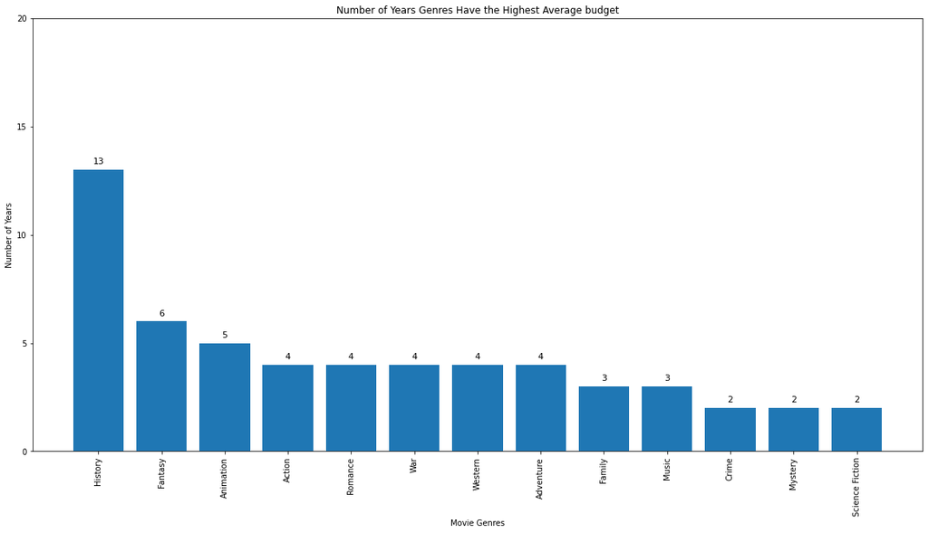

```python
budget_max = budget_mean.idxmax(axis = 1).value_counts()

plt.figure(figsize=(20, 10))
graph = plt.bar(budget_max.index, budget_max)

plt.title('Number of Years Genres Have the Highest Average budget')
plt.xticks(rotation = 'vertical')
plt.yticks([0, 5, 10, 15, 20])
plt.xlabel('Movie Genres')
plt.ylabel('Number of Years')

# Place the values above the bars.
for p in graph.patches:
    plt.annotate(p.get_height(), (p.get_x() + p.get_width() / 2, p.get_height()), ha = 'center', va = 'center', fontsize = 11, xytext = (0, 10), textcoords = 'offset points')
plt.show()
```

This means that history genre is the highest budget genre over the years

### Create revenue mean dataframe for each year per genere

### To get the most popular genere from 1960 to 2015 as per revenue

```python
revenue_mean = df.explode("newGenres").pivot_table(index="release_year", columns="newGenres", values='revenue_adj', aggfunc="mean", fill_value=0)
revenue_mean
```

| newGenres release_year | Action | Adventure | Animation | Comedy | Crime | Documentary | Drama | Family | Fantasy | Foreign | History | Horror | Music | Mystery | Romance | Science Fiction | TV Movie | Thriller | War | Western |
| --- | --- | --- | --- | --- | --- | --- | --- | --- | --- | --- | --- | --- | --- | --- | --- | --- | --- | --- | --- | --- |
| 1960 | 2.392712e+08 | 3.616441e+07 | 0.000000e+00 | 1.183361e+08 | 0.000000e+00 | 0.000000e+00 | 2.875457e+08 | 0.000000e+00 | 0.000000e+00 | 0.000000e+00 | 4.423780e+08 | 2.359350e+08 | 0.000000e+00 | 0.000000e+00 | 1.183361e+08 | 0.000000e+00 | 0.000000e+00 | 2.359350e+08 | 0.000000e+00 | 3.616441e+07 |
| 1961 | 1.210947e+08 | 8.928181e+08 | 1.574815e+09 | 4.274424e+08 | 3.184705e+08 | 0.000000e+00 | 1.356117e+08 | 8.019971e+08 | 0.000000e+00 | 0.000000e+00 | 7.294861e+07 | 1.458972e+07 | 3.184705e+08 | 0.000000e+00 | 6.930118e+07 | 0.000000e+00 | 0.000000e+00 | 0.000000e+00 | 2.108215e+08 | 3.136790e+07 |
| 1962 | 3.950230e+08 | 4.315458e+08 | 0.000000e+00 | 0.000000e+00 | 9.464582e+07 | 0.000000e+00 | 2.000054e+08 | 0.000000e+00 | 0.000000e+00 | 0.000000e+00 | 5.045914e+08 | 0.000000e+00 | 0.000000e+00 | 0.000000e+00 | 0.000000e+00 | 0.000000e+00 | 0.000000e+00 | 4.296236e+08 | 5.045914e+08 | 2.090450e+08 |
| 1963 | 3.164876e+08 | 2.986871e+08 | 0.000000e+00 | 9.594148e+07 | 0.000000e+00 | 0.000000e+00 | 1.726643e+08 | 0.000000e+00 | 0.000000e+00 | 0.000000e+00 | 1.726643e+08 | 8.119517e+07 | 0.000000e+00 | 9.594148e+07 | 2.535659e+08 | 0.000000e+00 | 0.000000e+00 | 2.311052e+08 | 3.560090e+07 | 0.000000e+00 |
| 1964 | 8.780804e+08 | 8.780804e+08 | 0.000000e+00 | 2.641355e+08 | 4.921187e+07 | 0.000000e+00 | 1.765305e+08 | 6.125919e+08 | 7.190046e+08 | 0.000000e+00 | 0.000000e+00 | 0.000000e+00 | 4.107393e+08 | 4.921187e+07 | 2.952712e+08 | 0.000000e+00 | 0.000000e+00 | 4.636461e+08 | 6.636764e+07 | 0.000000e+00 |
| 1965 | 5.922122e+08 | 5.922122e+08 | 0.000000e+00 | 2.072709e+08 | 0.000000e+00 | 0.000000e+00 | 6.619201e+08 | 1.129535e+09 | 0.000000e+00 | 0.000000e+00 | 8.304676e+07 | 0.000000e+00 | 1.129535e+09 | 0.000000e+00 | 9.513567e+08 | 0.000000e+00 | 0.000000e+00 | 9.771535e+08 | 7.731786e+08 | 0.000000e+00 |
| 1966 | 8.733419e+07 | 1.074882e+08 | 0.000000e+00 | 0.000000e+00 | 0.000000e+00 | 0.000000e+00 | 1.805019e+08 | 0.000000e+00 | 0.000000e+00 | 0.000000e+00 | 0.000000e+00 | 0.000000e+00 | 0.000000e+00 | 8.733419e+07 | 1.343603e+08 | 8.061618e+07 | 0.000000e+00 | 8.733419e+07 | 1.343603e+08 | 4.030809e+07 |
| 1967 | 4.327980e+08 | 5.405552e+08 | 1.345551e+09 | 2.795231e+08 | 1.720766e+08 | 0.000000e+00 | 2.954258e+08 | 7.021910e+08 | 5.883087e+07 | 0.000000e+00 | 0.000000e+00 | 0.000000e+00 | 1.928345e+08 | 1.789764e+08 | 3.481869e+08 | 0.000000e+00 | 0.000000e+00 | 3.267614e+08 | 2.961154e+08 | 0.000000e+00 |
| 1968 | 1.984154e+08 | 2.321832e+08 | 0.000000e+00 | 0.000000e+00 | 2.651826e+08 | 0.000000e+00 | 1.309283e+08 | 1.053186e+08 | 0.000000e+00 | 0.000000e+00 | 1.316482e+08 | 2.093547e+08 | 1.053186e+08 | 2.580853e+08 | 5.107112e+06 | 1.900028e+08 | 0.000000e+00 | 2.651826e+08 | 1.003034e+08 | 4.262895e+07 |
| 1969 | 4.872780e+08 | 2.455371e+08 | 0.000000e+00 | 0.000000e+00 | 6.081511e+08 | 0.000000e+00 | 4.371826e+08 | 0.000000e+00 | 0.000000e+00 | 0.000000e+00 | 6.081511e+08 | 0.000000e+00 | 0.000000e+00 | 0.000000e+00 | 0.000000e+00 | 0.000000e+00 | 0.000000e+00 | 4.872780e+08 | 0.000000e+00 | 3.059737e+08 |
| 1970 | 2.318114e+08 | 1.484452e+08 | 3.126928e+08 | 1.952641e+08 | 8.424553e+06 | 0.000000e+00 | 3.773373e+08 | 3.126928e+08 | 0.000000e+00 | 0.000000e+00 | 3.351520e+08 | 0.000000e+00 | 0.000000e+00 | 5.756698e+07 | 2.598506e+08 | 1.067094e+08 | 0.000000e+00 | 5.643841e+08 | 3.761999e+08 | 9.845368e+07 |
| 1971 | 2.601692e+08 | 3.449799e+08 | 0.000000e+00 | 0.000000e+00 | 1.110515e+08 | 0.000000e+00 | 1.189985e+08 | 2.154078e+07 | 2.154078e+07 | 0.000000e+00 | 0.000000e+00 | 0.000000e+00 | 5.602935e+07 | 1.531763e+07 | 5.655621e+07 | 2.118736e+08 | 0.000000e+00 | 1.977790e+08 | 0.000000e+00 | 0.000000e+00 |
| 1972 | 2.661079e+08 | 3.407337e+08 | 0.000000e+00 | 6.261720e+07 | 5.501334e+08 | 0.000000e+00 | 5.280417e+08 | 0.000000e+00 | 0.000000e+00 | 0.000000e+00 | 0.000000e+00 | 0.000000e+00 | 0.000000e+00 | 6.570347e+07 | 0.000000e+00 | 5.058124e+07 | 0.000000e+00 | 2.043314e+08 | 0.000000e+00 | 0.000000e+00 |
| 1973 | 3.224452e+08 | 7.945168e+08 | 1.574344e+08 | 4.795928e+08 | 2.764028e+08 | 0.000000e+00 | 5.640744e+08 | 1.574344e+08 | 0.000000e+00 | 0.000000e+00 | 1.463526e+08 | 2.167325e+09 | 0.000000e+00 | 0.000000e+00 | 9.009389e+07 | 6.676555e+07 | 0.000000e+00 | 1.134615e+09 | 0.000000e+00 | 0.000000e+00 |
| 1974 | 2.764212e+08 | 3.196692e+08 | 0.000000e+00 | 4.549940e+08 | 1.032717e+08 | 0.000000e+00 | 1.492315e+08 | 0.000000e+00 | 0.000000e+00 | 0.000000e+00 | 0.000000e+00 | 1.364673e+08 | 0.000000e+00 | 7.610751e+07 | 1.173373e+08 | 3.815252e+08 | 0.000000e+00 | 2.672940e+08 | 0.000000e+00 | 5.284629e+08 |
| 1975 | 0.000000e+00 | 9.636911e+08 | 0.000000e+00 | 2.157657e+08 | 1.890817e+08 | 0.000000e+00 | 1.741462e+08 | 0.000000e+00 | 2.037640e+07 | 0.000000e+00 | 0.000000e+00 | 1.182213e+09 | 2.981003e+08 | 0.000000e+00 | 8.103642e+07 | 4.574195e+08 | 0.000000e+00 | 1.048044e+09 | 8.103642e+07 | 0.000000e+00 |
| 1976 | 1.581858e+08 | 1.486976e+08 | 0.000000e+00 | 9.841907e+07 | 1.052422e+08 | 0.000000e+00 | 2.655925e+08 | 1.353482e+08 | 0.000000e+00 | 0.000000e+00 | 2.705179e+08 | 1.881842e+08 | 6.169034e+08 | 2.000782e+08 | 3.563479e+08 | 1.486976e+08 | 0.000000e+00 | 1.540138e+08 | 0.000000e+00 | 1.218480e+08 |
| 1977 | 6.267642e+08 | 5.678174e+08 | 1.442996e+08 | 1.246891e+08 | 9.503416e+07 | 0.000000e+00 | 2.835426e+08 | 1.568918e+08 | 9.639536e+07 | 0.000000e+00 | 1.825874e+08 | 6.797431e+07 | 4.824197e+08 | 4.526009e+06 | 1.376203e+08 | 6.764948e+08 | 0.000000e+00 | 1.714106e+08 | 1.825874e+08 | 0.000000e+00 |
| 1978 | 2.384893e+08 | 2.424676e+08 | 5.713543e+07 | 2.737088e+08 | 1.169945e+08 | 0.000000e+00 | 8.044860e+07 | 7.036068e+07 | 5.369498e+08 | 0.000000e+00 | 0.000000e+00 | 2.429802e+08 | 3.390548e+08 | 6.452518e+07 | 0.000000e+00 | 3.847600e+08 | 0.000000e+00 | 2.110440e+08 | 9.565138e+07 | 0.000000e+00 |
| 1979 | 2.482989e+08 | 3.142412e+08 | 0.000000e+00 | 7.190985e+07 | 1.291958e+08 | 0.000000e+00 | 2.100473e+08 | 1.106300e+08 | 0.000000e+00 | 0.000000e+00 | 7.042110e+07 | 1.756466e+08 | 0.000000e+00 | 4.176330e+08 | 7.042110e+07 | 3.014881e+08 | 0.000000e+00 | 3.216732e+08 | 2.507947e+08 | 0.000000e+00 |
| 1980 | 4.112022e+08 | 6.222057e+08 | 0.000000e+00 | 1.379295e+08 | 1.329221e+08 | 0.000000e+00 | 5.856491e+07 | 0.000000e+00 | 1.327527e+08 | 0.000000e+00 | 3.994667e+07 | 9.094194e+07 | 1.821816e+08 | 5.869715e+07 | 9.289379e+07 | 3.728517e+08 | 0.000000e+00 | 7.054873e+07 | 0.000000e+00 | 2.550716e+07 |
| 1981 | 3.057873e+08 | 2.890210e+08 | 7.146609e+07 | 1.441250e+08 | 4.773685e+07 | 0.000000e+00 | 9.927795e+07 | 9.053803e+07 | 7.151238e+07 | 0.000000e+00 | 1.191368e+08 | 4.231541e+07 | 0.000000e+00 | 9.845505e+06 | 1.298681e+08 | 7.125835e+07 | 0.000000e+00 | 9.436039e+07 | 0.000000e+00 | 0.000000e+00 |
| 1982 | 1.395554e+08 | 4.472067e+08 | 3.313931e+07 | 1.417627e+08 | 8.910733e+07 | 0.000000e+00 | 1.152460e+08 | 4.970122e+08 | 4.239241e+08 | 0.000000e+00 | 1.756598e+08 | 9.404707e+07 | 8.160753e+07 | 3.184157e+07 | 1.144940e+08 | 3.403504e+08 | 0.000000e+00 | 1.284636e+08 | 1.530811e+08 | 4.668291e+07 |
| 1983 | 2.731518e+08 | 3.354633e+08 | 2.382068e+07 | 1.422618e+08 | 7.891211e+07 | 0.000000e+00 | 8.790988e+07 | 4.597555e+07 | 6.111896e+07 | 8.016729e+06 | 4.707021e+07 | 5.921050e+07 | 1.373530e+08 | 2.906668e+07 | 1.151759e+08 | 1.861352e+08 | 0.000000e+00 | 1.217197e+08 | 0.000000e+00 | 2.678104e+07 |
| 1984 | 1.869033e+08 | 1.339484e+08 | 0.000000e+00 | 1.588110e+08 | 2.423539e+08 | 1.045097e+07 | 7.982346e+07 | 2.766584e+08 | 1.637505e+08 | 0.000000e+00 | 7.966632e+07 | 7.383231e+07 | 8.375120e+07 | 1.847564e+07 | 1.149019e+08 | 1.174123e+08 | 0.000000e+00 | 7.186449e+07 | 6.036079e+07 | 0.000000e+00 |
| 1985 | 1.246482e+08 | 1.489527e+08 | 4.315571e+07 | 9.271272e+07 | 8.448315e+07 | 0.000000e+00 | 1.619509e+08 | 1.784475e+08 | 2.787128e+07 | 0.000000e+00 | 0.000000e+00 | 3.970705e+07 | 0.000000e+00 | 2.968581e+07 | 6.380646e+07 | 1.442449e+08 | 0.000000e+00 | 1.349641e+08 | 3.153823e+08 | 0.000000e+00 |
| 1986 | 1.344249e+08 | 1.421059e+08 | 1.639764e+08 | 1.063148e+08 | 3.054056e+07 | 0.000000e+00 | 1.145027e+08 | 8.262958e+07 | 3.287845e+07 | 0.000000e+00 | 3.425365e+07 | 4.943223e+07 | 4.135470e+07 | 6.977729e+07 | 1.358664e+08 | 7.893940e+07 | 0.000000e+00 | 7.609743e+07 | 1.802945e+08 | 0.000000e+00 |
| 1987 | 1.536158e+08 | 1.409064e+08 | 0.000000e+00 | 1.116480e+08 | 1.445334e+08 | 0.000000e+00 | 1.356962e+08 | 9.836862e+07 | 3.354298e+07 | 0.000000e+00 | 1.153892e+08 | 8.960973e+07 | 2.573196e+08 | 3.518004e+07 | 1.366695e+08 | 6.455149e+07 | 0.000000e+00 | 1.659993e+08 | 1.633906e+08 | 0.000000e+00 |
| 1988 | 8.718470e+07 | 1.084883e+08 | 3.819296e+08 | 1.250281e+08 | 1.148943e+08 | 1.086502e+06 | 1.092264e+08 | 1.905781e+08 | 2.061819e+08 | 1.273907e+07 | 7.730402e+06 | 2.637713e+07 | 4.153869e+06 | 3.252246e+07 | 1.798298e+08 | 1.855250e+07 | 0.000000e+00 | 6.379827e+07 | 1.781273e+08 | 0.000000e+00 |
| 1989 | 2.524590e+08 | 2.416945e+08 | 2.097093e+08 | 1.643496e+08 | 1.153275e+08 | 0.000000e+00 | 1.090625e+08 | 2.424967e+08 | 2.563799e+08 | 0.000000e+00 | 3.284257e+07 | 4.177885e+07 | 0.000000e+00 | 1.284327e+08 | 1.682889e+08 | 2.159409e+08 | 0.000000e+00 | 9.032449e+07 | 1.210776e+08 | 0.000000e+00 |
| 1990 | 1.506418e+08 | 2.254001e+08 | 4.661477e+07 | 1.912074e+08 | 7.653720e+07 | 6.307802e+06 | 1.339636e+08 | 3.228963e+08 | 1.393403e+08 | 0.000000e+00 | 0.000000e+00 | 4.056618e+07 | 1.379569e+07 | 1.930055e+08 | 2.598779e+08 | 1.443633e+08 | 0.000000e+00 | 1.298892e+08 | 0.000000e+00 | 7.079615e+08 |
| 1991 | 1.485907e+08 | 1.524310e+08 | 3.114189e+08 | 9.597656e+07 | 1.432862e+08 | 0.000000e+00 | 1.395310e+08 | 1.826878e+08 | 2.403438e+08 | 0.000000e+00 | 3.288733e+08 | 4.437612e+07 | 1.699632e+08 | 1.311932e+08 | 2.019363e+08 | 1.863162e+08 | 0.000000e+00 | 1.611626e+08 | 2.899518e+08 | 1.985896e+08 |
| 1992 | 1.578930e+08 | 2.642706e+08 | 7.833063e+08 | 1.823790e+08 | 1.621704e+08 | 0.000000e+00 | 1.056005e+08 | 2.855348e+08 | 4.135819e+08 | 1.299120e+07 | 6.779025e+07 | 9.723717e+07 | 4.993172e+08 | 1.473230e+08 | 1.959269e+08 | 1.428755e+08 | 0.000000e+00 | 1.702881e+08 | 1.947963e+07 | 2.307270e+08 |
| 1993 | 1.312835e+08 | 2.428645e+08 | 6.132358e+07 | 1.199526e+08 | 9.343258e+07 | 0.000000e+00 | 1.256050e+08 | 1.674619e+08 | 8.659314e+07 | 3.680135e+06 | 1.925223e+08 | 1.740714e+07 | 8.652135e+07 | 2.124445e+08 | 6.293310e+07 | 2.775688e+08 | 0.000000e+00 | 1.121998e+08 | 3.434184e+08 | 5.671130e+07 |
| 1994 | 1.497072e+08 | 1.261239e+08 | 2.421829e+08 | 1.401792e+08 | 1.734982e+08 | 1.151970e+07 | 2.076826e+08 | 2.275771e+08 | 1.370510e+08 | 0.000000e+00 | 8.661106e+06 | 1.048042e+08 | 0.000000e+00 | 1.402452e+08 | 2.586651e+08 | 9.829481e+07 | 0.000000e+00 | 1.612308e+08 | 1.360566e+08 | 1.365860e+08 |
| 1995 | 2.014791e+08 | 1.615115e+08 | 3.396268e+08 | 1.167875e+08 | 1.996630e+08 | 0.000000e+00 | 1.468123e+08 | 2.568389e+08 | 2.158327e+08 | 0.000000e+00 | 1.116460e+08 | 3.665625e+07 | 0.000000e+00 | 3.666332e+08 | 8.094473e+07 | 1.318216e+08 | 0.000000e+00 | 1.645208e+08 | 1.609838e+08 | 2.654796e+07 |
| 1996 | 2.138860e+08 | 2.396699e+08 | 1.663905e+08 | 9.276814e+07 | 1.064777e+08 | 0.000000e+00 | 1.072275e+08 | 1.714179e+08 | 1.165545e+08 | 0.000000e+00 | 6.866163e+07 | 5.140622e+07 | 1.012538e+08 | 1.310663e+08 | 8.775763e+07 | 1.877359e+08 | 5.838910e+07 | 1.303940e+08 | 2.313580e+08 | 0.000000e+00 |
| 1997 | 1.720660e+08 | 2.008686e+08 | 1.793544e+08 | 1.658427e+08 | 1.134885e+08 | 8.150762e+07 | 1.374076e+08 | 1.386792e+08 | 1.761781e+08 | 0.000000e+00 | 9.898106e+07 | 1.193024e+08 | 7.034558e+07 | 1.051187e+08 | 3.995839e+08 | 1.949329e+08 | 0.000000e+00 | 1.835609e+08 | 1.785800e+08 | 0.000000e+00 |
| 1998 | 1.776577e+08 | 1.933591e+08 | 3.538505e+08 | 1.184642e+08 | 9.086357e+07 | 0.000000e+00 | 1.107853e+08 | 2.635413e+08 | 1.565212e+08 | 0.000000e+00 | 3.181829e+08 | 6.102472e+07 | 8.658807e+07 | 7.882385e+07 | 1.369611e+08 | 1.619859e+08 | 0.000000e+00 | 1.524665e+08 | 2.651024e+08 | 3.348098e+08 |
| 1999 | 1.923213e+08 | 2.789222e+08 | 1.999739e+08 | 9.602808e+07 | 1.335937e+08 | 0.000000e+00 | 1.129510e+08 | 1.176938e+08 | 1.797604e+08 | 0.000000e+00 | 8.767554e+07 | 1.141772e+08 | 1.189596e+08 | 1.757618e+08 | 9.087798e+07 | 1.612287e+08 | 0.000000e+00 | 1.249412e+08 | 3.866636e+07 | 8.313742e+05 |
| 2000 | 1.648207e+08 | 2.087775e+08 | 1.704587e+08 | 1.340591e+08 | 1.149273e+08 | 0.000000e+00 | 1.058503e+08 | 1.702914e+08 | 1.571737e+08 | 1.716584e+07 | 1.812661e+08 | 8.163013e+07 | 6.628857e+07 | 6.838281e+07 | 1.219272e+08 | 9.305210e+07 | 0.000000e+00 | 1.268629e+08 | 1.747317e+08 | 7.209293e+07 |
| 2001 | 1.569804e+08 | 2.983365e+08 | 2.251798e+08 | 1.072215e+08 | 1.222187e+08 | 0.000000e+00 | 9.553287e+07 | 3.036534e+08 | 4.073076e+08 | 0.000000e+00 | 2.809121e+08 | 1.436276e+08 | 1.179124e+08 | 6.778678e+07 | 1.305026e+08 | 1.833224e+08 | 0.000000e+00 | 1.360512e+08 | 2.496658e+08 | 1.684542e+07 |
| 2002 | 1.890974e+08 | 2.621913e+08 | 2.103253e+08 | 1.230306e+08 | 1.302617e+08 | 1.495616e+07 | 9.094678e+07 | 2.031079e+08 | 4.405701e+08 | 1.774775e+05 | 1.276604e+08 | 1.087644e+08 | 1.472407e+08 | 1.541031e+08 | 7.278051e+07 | 2.212062e+08 | 0.000000e+00 | 9.912548e+07 | 9.080597e+07 | 1.485790e+08 |
| 2003 | 2.253212e+08 | 2.723117e+08 | 2.163485e+08 | 1.317656e+08 | 1.070928e+08 | 2.019944e+07 | 8.342627e+07 | 1.855975e+08 | 3.040858e+08 | 0.000000e+00 | 1.831427e+08 | 7.480963e+07 | 7.198603e+07 | 8.033658e+07 | 8.889951e+07 | 2.626038e+08 | 0.000000e+00 | 1.454966e+08 | 2.194148e+08 | 9.282484e+07 |
| 2004 | 1.660824e+08 | 2.561145e+08 | 3.491195e+08 | 1.027752e+08 | 9.151447e+07 | 4.455312e+07 | 9.661556e+07 | 2.856123e+08 | 3.881433e+08 | 0.000000e+00 | 1.152441e+08 | 1.077208e+08 | 3.838731e+07 | 1.280389e+08 | 8.257584e+07 | 1.748316e+08 | 0.000000e+00 | 1.183932e+08 | 2.152108e+08 | 9.153785e+07 |
| 2005 | 1.380455e+08 | 2.160690e+08 | 2.373479e+08 | 1.067279e+08 | 7.066536e+07 | 6.907181e+06 | 8.084131e+07 | 1.910871e+08 | 2.131633e+08 | 0.000000e+00 | 1.129464e+08 | 6.866199e+07 | 8.599357e+07 | 7.172859e+07 | 9.763940e+07 | 2.163492e+08 | 0.000000e+00 | 9.139761e+07 | 1.186161e+08 | 8.621890e+07 |
| 2006 | 1.568608e+08 | 1.981777e+08 | 2.077600e+08 | 9.883992e+07 | 8.265732e+07 | 4.351937e+07 | 6.290185e+07 | 1.525718e+08 | 1.953735e+08 | 0.000000e+00 | 6.613972e+07 | 6.486480e+07 | 1.478312e+08 | 1.032612e+08 | 7.155052e+07 | 9.059071e+07 | 0.000000e+00 | 1.129085e+08 | 3.488712e+07 | 1.294008e+06 |
| 2007 | 1.788870e+08 | 3.106578e+08 | 3.644529e+08 | 1.282688e+08 | 6.620179e+07 | 2.844780e+07 | 7.249470e+07 | 3.008869e+08 | 3.515567e+08 | 1.083613e+06 | 5.880684e+07 | 7.912384e+07 | 1.014595e+08 | 1.670769e+08 | 7.106222e+07 | 1.438791e+08 | 0.000000e+00 | 9.647569e+07 | 1.621802e+08 | 4.455289e+07 |
| 2008 | 1.499636e+08 | 1.494236e+08 | 2.387775e+08 | 9.485488e+07 | 1.171224e+08 | 7.798457e+06 | 7.962749e+07 | 2.108403e+08 | 2.160767e+08 | 3.375955e+07 | 5.602015e+07 | 4.358450e+07 | 4.875391e+07 | 6.923291e+07 | 1.206323e+08 | 9.371312e+07 | 0.000000e+00 | 1.115011e+08 | 4.323142e+07 | 2.046983e+07 |
| 2009 | 2.284361e+08 | 3.423672e+08 | 3.088570e+08 | 1.115270e+08 | 5.344308e+07 | 1.772248e+07 | 7.417192e+07 | 2.440802e+08 | 3.375589e+08 | 0.000000e+00 | 8.218843e+07 | 5.136467e+07 | 1.633406e+08 | 6.590356e+07 | 9.151085e+07 | 2.489458e+08 | 0.000000e+00 | 8.469747e+07 | 1.460834e+08 | 0.000000e+00 |
| 2010 | 1.478635e+08 | 3.052478e+08 | 4.149804e+08 | 1.034411e+08 | 6.287847e+07 | 2.802229e+06 | 6.860483e+07 | 3.589463e+08 | 2.950383e+08 | 2.802127e+06 | 1.127275e+08 | 5.905764e+07 | 2.995811e+06 | 1.358160e+08 | 1.051115e+08 | 1.825685e+08 | 0.000000e+00 | 8.392287e+07 | 1.149771e+08 | 9.130117e+07 |
| 2011 | 1.697677e+08 | 3.191203e+08 | 3.033056e+08 | 9.925931e+07 | 8.688536e+07 | 3.197944e+07 | 5.063393e+07 | 2.715498e+08 | 3.102186e+08 | 0.000000e+00 | 6.491573e+07 | 5.111230e+07 | 1.355436e+08 | 1.252674e+08 | 8.048938e+07 | 1.915925e+08 | 0.000000e+00 | 8.565386e+07 | 4.450372e+07 | 2.038387e+08 |
| 2012 | 2.517074e+08 | 4.354318e+08 | 3.415256e+08 | 1.171823e+08 | 1.051750e+08 | 3.140185e+07 | 1.111593e+08 | 3.191682e+08 | 3.727607e+08 | 0.000000e+00 | 8.698997e+07 | 5.802966e+07 | 1.104979e+08 | 1.048854e+08 | 1.004561e+08 | 2.187484e+08 | 0.000000e+00 | 1.016887e+08 | 8.581066e+07 | 4.039911e+08 |
| 2013 | 1.934522e+08 | 2.957280e+08 | 3.541762e+08 | 1.235817e+08 | 8.778183e+07 | 0.000000e+00 | 6.638038e+07 | 3.040115e+08 | 3.081441e+08 | 0.000000e+00 | 5.829749e+07 | 8.940054e+07 | 1.960361e+07 | 5.693427e+07 | 4.474421e+07 | 3.265119e+08 | 0.000000e+00 | 1.130850e+08 | 1.017586e+08 | 4.179204e+07 |
| 2014 | 2.752181e+08 | 3.726183e+08 | 2.983466e+08 | 1.307060e+08 | 5.439097e+07 | 0.000000e+00 | 7.289733e+07 | 2.418545e+08 | 3.784758e+08 | 0.000000e+00 | 1.319830e+08 | 4.694782e+07 | 9.473052e+07 | 1.170205e+08 | 9.114458e+07 | 3.018780e+08 | 0.000000e+00 | 1.203088e+08 | 1.927989e+08 | 2.238241e+06 |
| 2015 | 3.285209e+08 | 3.606188e+08 | 3.921834e+08 | 1.302134e+08 | 1.720898e+08 | 0.000000e+00 | 7.053351e+07 | 3.390260e+08 | 2.861134e+08 | 0.000000e+00 | 4.738260e+07 | 5.147060e+07 | 6.969902e+07 | 6.284613e+07 | 8.554563e+07 | 4.018570e+08 | 0.000000e+00 | 1.511364e+08 | 1.274942e+08 | 3.168067e+08 |

```python
revenue_mean.idxmax(axis = 1)
```

```
release_year
1960            History
1961          Animation
1962            History
1963             Action
1964             Action
1965             Family
1966              Drama
1967          Animation
1968              Crime
1969              Crime
1970           Thriller
1971          Adventure
1972              Crime
1973             Horror
```

[output cut: 43 more lines]

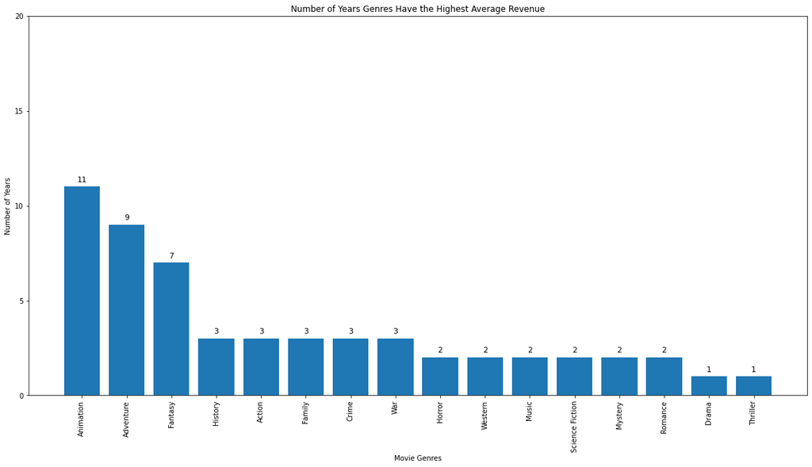

```python
revenue_max = revenue_mean.idxmax(axis = 1).value_counts()

plt.figure(figsize=(20, 10))
graph = plt.bar(revenue_max.index, revenue_max)

plt.title('Number of Years Genres Have the Highest Average Revenue')
plt.xticks(rotation = 'vertical')
plt.yticks([0, 5, 10, 15, 20])
plt.xlabel('Movie Genres')
plt.ylabel('Number of Years')

# Place the values above the bars.
for p in graph.patches:
    plt.annotate(p.get_height(), (p.get_x() + p.get_width() / 2, p.get_height()), ha = 'center', va = 'center', fontsize = 11, xytext = (0, 10), textcoords = 'offset points')
plt.show()
```

This means that Animation genre is the highest revenue genre over the years

### Create profit mean dataframe for each year per genere

### To get the most popular genere from 1960 to 2015 as per profit

```python
profit_mean = df.explode("newGenres").pivot_table(index="release_year", columns="newGenres", values='profit', aggfunc="mean", fill_value=0)
profit_mean
```

| newGenres release_year | Action | Adventure | Animation | Comedy | Crime | Documentary | Drama | Family | Fantasy | Foreign | History | Horror | Music | Mystery | Romance | Science Fiction | TV Movie | Thriller | War | Western |
| --- | --- | --- | --- | --- | --- | --- | --- | --- | --- | --- | --- | --- | --- | --- | --- | --- | --- | --- | --- | --- |
| 1960 | 2.545250e+07 | 2.905000e+06 | 0.000000e+00 | 1.305000e+07 | 0.000000e+00 | 0.000000e+00 | 3.373102e+07 | 0.000000e+00 | 0.000000e+00 | 0.000000e+00 | 4.800000e+07 | 3.119305e+07 | 0.000000e+00 | 0.000000e+00 | 1.305000e+07 | 0.000000e+00 | 0 | 3.119305e+07 | 0.000000e+00 | 2.905000e+06 |
| 1961 | 1.060000e+07 | 1.173900e+08 | 2.118800e+08 | 5.549500e+07 | 3.765682e+07 | 0.000000e+00 | 1.435053e+07 | 1.064400e+08 | 0.000000e+00 | 0.000000e+00 | 7.000000e+06 | 1.800000e+06 | 3.765682e+07 | 0.000000e+00 | 7.000000e+06 | 0.000000e+00 | 0 | 0.000000e+00 | 2.290000e+07 | -1.700000e+06 |
| 1962 | 4.675000e+07 | 4.950000e+07 | 0.000000e+00 | 0.000000e+00 | 1.112985e+07 | 0.000000e+00 | 2.071597e+07 | 0.000000e+00 | 0.000000e+00 | 0.000000e+00 | 5.500000e+07 | 0.000000e+00 | 0.000000e+00 | 0.000000e+00 | 0.000000e+00 | 0.000000e+00 | 0 | 5.850000e+07 | 5.500000e+07 | 1.990000e+07 |
| 1963 | 3.469938e+07 | 3.869938e+07 | 0.000000e+00 | 9.474588e+06 | 0.000000e+00 | 0.000000e+00 | 6.878333e+06 | 0.000000e+00 | 0.000000e+00 | 0.000000e+00 | 6.878333e+06 | 8.903529e+06 | 0.000000e+00 | 9.474588e+06 | 1.805479e+07 | 0.000000e+00 | 0 | 2.895778e+07 | 1.000000e+06 | 0.000000e+00 |
| 1964 | 1.214000e+08 | 1.214000e+08 | 0.000000e+00 | 3.480452e+07 | 4.864839e+06 | 0.000000e+00 | 1.912628e+07 | 7.563636e+07 | 9.627273e+07 | 0.000000e+00 | 0.000000e+00 | 0.000000e+00 | 5.059109e+07 | 4.864839e+06 | 3.200000e+07 | 0.000000e+00 | 0 | 6.313242e+07 | 7.640272e+06 | 0.000000e+00 |
| 1965 | 7.727283e+07 | 7.727283e+07 | 0.000000e+00 | 2.435000e+07 | 0.000000e+00 | 0.000000e+00 | 8.157873e+07 | 1.550143e+08 | 0.000000e+00 | 0.000000e+00 | -8.000000e+06 | 0.000000e+00 | 1.550143e+08 | 0.000000e+00 | 1.263681e+08 | 0.000000e+00 | 0 | 1.301957e+08 | 9.772191e+07 | 0.000000e+00 |
| 1966 | 4.673500e+06 | 7.442500e+06 | 0.000000e+00 | 0.000000e+00 | 0.000000e+00 | 0.000000e+00 | 1.711834e+07 | 0.000000e+00 | 0.000000e+00 | 0.000000e+00 | 0.000000e+00 | 0.000000e+00 | 0.000000e+00 | 1.000000e+07 | 8.000000e+06 | 6.885000e+06 | 0 | 1.000000e+07 | 8.000000e+06 | 1.347000e+06 |
| 1967 | 5.070984e+07 | 6.899462e+07 | 2.018436e+08 | 3.466170e+07 | 2.344944e+07 | 0.000000e+00 | 4.183736e+07 | 9.642181e+07 | -9.000000e+06 | 0.000000e+00 | 0.000000e+00 | 0.000000e+00 | 1.800000e+07 | 2.537998e+07 | 4.939094e+07 | 0.000000e+00 | 0 | 4.482159e+07 | 2.030000e+07 | 0.000000e+00 |
| 1968 | 2.505044e+07 | 2.853693e+07 | 0.000000e+00 | 0.000000e+00 | 3.680087e+07 | 0.000000e+00 | 1.516016e+07 | 6.800000e+06 | 0.000000e+00 | 0.000000e+00 | 1.330000e+07 | 3.019543e+07 | 6.800000e+06 | 3.416874e+07 | -1.353340e+05 | 2.405849e+07 | 0 | 3.680087e+07 | 8.650000e+06 | 5.000000e+06 |
| 1969 | 7.497449e+07 | 3.468452e+07 | 0.000000e+00 | 0.000000e+00 | 9.630889e+07 | 0.000000e+00 | 6.874697e+07 | 0.000000e+00 | 0.000000e+00 | 0.000000e+00 | 9.630889e+07 | 0.000000e+00 | 0.000000e+00 | 0.000000e+00 | 0.000000e+00 | 0.000000e+00 | 0 | 7.497449e+07 | 0.000000e+00 | 4.535172e+07 |
| 1970 | 2.772376e+07 | 1.580957e+07 | 5.167526e+07 | 2.752357e+07 | -8.500000e+06 | 0.000000e+00 | 5.644457e+07 | 5.167526e+07 | 0.000000e+00 | 0.000000e+00 | 4.093165e+07 | 0.000000e+00 | 0.000000e+00 | 3.749859e+06 | 3.986667e+07 | 1.599972e+07 | 0 | 9.048915e+07 | 5.332110e+07 | 8.171303e+06 |
| 1971 | 4.484526e+07 | 5.846081e+07 | 0.000000e+00 | 0.000000e+00 | 1.807663e+07 | 0.000000e+00 | 1.959706e+07 | 1.000000e+06 | 1.000000e+06 | 0.000000e+00 | 0.000000e+00 | 0.000000e+00 | 1.404330e+06 | 1.355897e+06 | 5.639665e+06 | 3.617448e+07 | 0 | 3.397618e+07 | 0.000000e+00 | 0.000000e+00 |
| 1972 | 4.764762e+07 | 6.184274e+07 | 0.000000e+00 | 1.100214e+07 | 1.012154e+08 | 0.000000e+00 | 9.742959e+07 | 0.000000e+00 | 0.000000e+00 | 0.000000e+00 | 0.000000e+00 | 0.000000e+00 | 0.000000e+00 | 9.100000e+06 | 0.000000e+00 | 7.900000e+06 | 0 | 3.623403e+07 | 0.000000e+00 | 0.000000e+00 |
| 1973 | 6.301811e+07 | 1.547778e+08 | 1.705647e+07 | 9.489469e+07 | 5.247222e+07 | 0.000000e+00 | 1.104589e+08 | 1.705647e+07 | 0.000000e+00 | 0.000000e+00 | 2.680000e+07 | 4.333061e+08 | 0.000000e+00 | 0.000000e+00 | 1.634473e+07 | 1.174466e+07 | 0 | 2.257447e+08 | 0.000000e+00 | 0.000000e+00 |
| 1974 | 5.633978e+07 | 6.728600e+07 | 0.000000e+00 | 1.001867e+08 | 1.803257e+07 | 0.000000e+00 | 2.835784e+07 | 0.000000e+00 | 0.000000e+00 | 0.000000e+00 | 0.000000e+00 | 3.077400e+07 | 0.000000e+00 | 1.341000e+07 | 2.003320e+07 | 8.347333e+07 | 0 | 5.471609e+07 | 0.000000e+00 | 1.169000e+08 |
| 1975 | 0.000000e+00 | 2.341415e+08 | 0.000000e+00 | 5.105154e+07 | 4.486586e+07 | 0.000000e+00 | 3.827973e+07 | 0.000000e+00 | 4.628948e+06 | 0.000000e+00 | 0.000000e+00 | 2.876732e+08 | 7.047192e+07 | 0.000000e+00 | 9.000000e+06 | 1.116923e+08 | 0 | 2.542599e+08 | 9.000000e+06 | 0.000000e+00 |
| 1976 | 2.728348e+07 | 2.230722e+07 | 0.000000e+00 | 1.135216e+07 | 2.336619e+07 | 0.000000e+00 | 6.240029e+07 | 3.232920e+05 | 0.000000e+00 | 0.000000e+00 | 6.210000e+07 | 3.957914e+07 | 1.550000e+08 | 4.496660e+07 | 8.550000e+07 | 2.230722e+07 | 0 | 3.509467e+07 | 0.000000e+00 | 2.810000e+07 |
| 1977 | 1.638752e+08 | 1.487243e+08 | 3.890793e+07 | 3.095723e+07 | 2.091466e+07 | 0.000000e+00 | 7.127486e+07 | 4.125793e+07 | 2.281100e+07 | 0.000000e+00 | 2.875000e+07 | 1.474540e+07 | 1.306381e+08 | 4.480000e+05 | 3.425142e+07 | 1.819961e+08 | 0 | 3.725841e+07 | 2.875000e+07 | 0.000000e+00 |
| 1978 | 5.558629e+07 | 5.473645e+07 | 1.459259e+07 | 7.453254e+07 | 3.270000e+07 | 0.000000e+00 | 1.819552e+07 | -2.950947e+06 | 1.211335e+08 | 0.000000e+00 | 0.000000e+00 | 6.643978e+07 | 8.643141e+07 | 1.359331e+07 | 0.000000e+00 | 8.760453e+07 | 0 | 5.601578e+07 | 1.861500e+07 | 0.000000e+00 |
| 1979 | 6.357419e+07 | 8.616831e+07 | 0.000000e+00 | 1.016695e+07 | 3.500000e+07 | 0.000000e+00 | 5.729535e+07 | 2.547077e+07 | 0.000000e+00 | 0.000000e+00 | 5.938120e+06 | 5.281014e+07 | 0.000000e+00 | 1.040000e+08 | 5.938120e+06 | 8.356036e+07 | 0 | 9.221187e+07 | 5.197151e+07 | 0.000000e+00 |
| 1980 | 1.252030e+08 | 2.096463e+08 | 0.000000e+00 | 4.122682e+07 | 3.723441e+07 | 0.000000e+00 | 8.570568e+06 | 0.000000e+00 | 2.050373e+07 | 0.000000e+00 | -4.569872e+06 | 2.875911e+07 | 4.535074e+07 | 1.468304e+07 | 2.677343e+07 | 1.161095e+08 | 0 | 1.740204e+07 | 0.000000e+00 | -1.736024e+07 |
| 1981 | 1.160075e+08 | 1.071829e+08 | 1.780000e+07 | 5.161961e+07 | 1.490536e+07 | 0.000000e+00 | 2.870952e+07 | 2.708597e+07 | 1.715264e+07 | 0.000000e+00 | 3.092778e+07 | 1.465097e+07 | 0.000000e+00 | -3.477945e+06 | 4.688588e+07 | 2.309338e+07 | 0 | 3.105760e+07 | 0.000000e+00 | 0.000000e+00 |
| 1982 | 5.094746e+07 | 1.824937e+08 | 7.665733e+06 | 4.645344e+07 | 3.893426e+07 | 0.000000e+00 | 3.536021e+07 | 1.997767e+08 | 1.755067e+08 | 0.000000e+00 | 5.573789e+07 | 3.458033e+07 | 4.515240e+06 | 7.841419e+06 | 3.952909e+07 | 1.366213e+08 | 0 | 4.585129e+07 | 5.724574e+07 | 1.715942e+07 |
| 1983 | 1.006811e+08 | 1.282491e+08 | 8.780442e+06 | 4.352012e+07 | 2.037758e+07 | 0.000000e+00 | 2.402078e+07 | 1.800000e+07 | 1.061697e+07 | -2.338243e+06 | -5.500000e+06 | 1.877711e+07 | 5.007129e+07 | 5.682378e+06 | 4.107495e+07 | 6.876973e+07 | 0 | 3.952609e+07 | 0.000000e+00 | 7.232628e+06 |
| 1984 | 7.088906e+07 | 4.440044e+07 | 0.000000e+00 | 6.431506e+07 | 8.983427e+07 | 3.778922e+06 | 2.242491e+07 | 1.100689e+08 | 6.291201e+07 | 0.000000e+00 | 2.448699e+07 | 3.169572e+07 | 2.204972e+07 | -1.198060e+06 | 3.761158e+07 | 3.864977e+07 | 0 | 2.383055e+07 | 2.028135e+07 | 0.000000e+00 |
| 1985 | 4.456258e+07 | 5.270678e+07 | -3.711308e+06 | 3.372987e+07 | 2.817550e+07 | 0.000000e+00 | 6.627135e+07 | 6.402804e+07 | -1.166540e+07 | 0.000000e+00 | 0.000000e+00 | 1.590175e+07 | 0.000000e+00 | -3.560030e+05 | 1.532569e+07 | 5.176943e+07 | 0 | 5.300773e+07 | 1.323729e+08 | 0.000000e+00 |
| 1986 | 5.412751e+07 | 5.118128e+07 | 6.842479e+07 | 3.735924e+07 | 6.965879e+06 | 0.000000e+00 | 4.686149e+07 | 2.853476e+07 | -1.558950e+06 | 0.000000e+00 | -7.281977e+06 | 1.539058e+07 | 6.287459e+06 | 2.540776e+07 | 5.888384e+07 | 2.530987e+07 | 0 | 2.475132e+07 | 8.012729e+07 | 0.000000e+00 |
| 1987 | 6.004655e+07 | 5.396677e+07 | 0.000000e+00 | 4.684180e+07 | 5.911389e+07 | 0.000000e+00 | 5.668118e+07 | 4.345821e+07 | 7.178674e+06 | 0.000000e+00 | 3.612734e+07 | 3.990910e+07 | 1.278348e+08 | 5.265049e+06 | 6.042705e+07 | 1.642418e+07 | 0 | 6.824939e+07 | 7.014002e+07 | 0.000000e+00 |
| 1988 | 2.999728e+07 | 3.600807e+07 | 1.659824e+08 | 5.087865e+07 | 4.341987e+07 | -1.910756e+06 | 4.520211e+07 | 8.347315e+07 | 8.981889e+07 | -8.091203e+06 | -1.180756e+07 | 8.249592e+06 | -3.997226e+06 | -2.362050e+06 | 7.908290e+07 | -5.633982e+05 | 0 | 2.293665e+07 | 5.710403e+07 | 0.000000e+00 |
| 1989 | 1.135505e+08 | 1.077443e+08 | 9.232175e+07 | 7.476999e+07 | 4.880038e+07 | 0.000000e+00 | 4.693229e+07 | 1.140117e+08 | 1.209945e+08 | 0.000000e+00 | -3.828683e+06 | 1.482311e+07 | 0.000000e+00 | 5.949236e+07 | 7.697387e+07 | 9.495199e+07 | 0 | 3.263160e+07 | 5.066713e+07 | 0.000000e+00 |
| 1990 | 6.271156e+07 | 1.007473e+08 | -9.999539e+06 | 9.068213e+07 | 2.040155e+07 | 3.279620e+06 | 5.686156e+07 | 1.651925e+08 | 5.937599e+07 | 0.000000e+00 | 0.000000e+00 | 1.033023e+07 | -2.733657e+06 | 9.184840e+07 | 1.354325e+08 | 6.272940e+07 | 0 | 5.477928e+07 | 0.000000e+00 | 4.022088e+08 |
| 1991 | 6.052005e+07 | 6.078770e+07 | 1.730040e+08 | 3.517168e+07 | 6.692135e+07 | 0.000000e+00 | 6.394734e+07 | 8.421304e+07 | 1.191123e+08 | 0.000000e+00 | 1.654055e+08 | 1.571614e+07 | 8.440447e+07 | 3.343981e+07 | 1.051240e+08 | 7.686814e+07 | 0 | 7.278288e+07 | 1.550962e+08 | 9.803379e+07 |
| 1992 | 7.300149e+07 | 1.359445e+08 | 4.760502e+08 | 9.512385e+07 | 8.461469e+07 | 0.000000e+00 | 4.462308e+07 | 1.570723e+08 | 2.168028e+08 | -1.640283e+06 | 3.289054e+06 | 4.582121e+07 | 2.933059e+08 | 7.192595e+07 | 9.898895e+07 | 5.393903e+07 | 0 | 8.954126e+07 | 7.534961e+06 | 1.114706e+08 |
| 1993 | 5.833041e+07 | 1.241796e+08 | 2.862590e+07 | 5.568846e+07 | 4.196428e+07 | 0.000000e+00 | 6.240897e+07 | 8.354086e+07 | 2.609992e+07 | -2.256197e+07 | 1.002097e+08 | 2.900230e+06 | 1.931903e+07 | 1.133760e+08 | 2.500647e+07 | 1.567183e+08 | 0 | 5.119920e+07 | 2.040093e+08 | 7.570342e+06 |
| 1994 | 6.305518e+07 | 5.814372e+07 | 1.330258e+08 | 7.298399e+07 | 9.055110e+07 | 7.130611e+06 | 1.089120e+08 | 1.221330e+08 | 6.907816e+07 | 0.000000e+00 | -1.211254e+07 | 4.692152e+07 | 0.000000e+00 | 6.153279e+07 | 1.385797e+08 | 3.386669e+07 | 0 | 7.459797e+07 | 5.748560e+07 | 4.634544e+07 |
| 1995 | 9.314411e+07 | 6.404529e+07 | 1.996741e+08 | 6.081229e+07 | 1.068878e+08 | 0.000000e+00 | 7.513780e+07 | 1.471529e+08 | 1.149411e+08 | 0.000000e+00 | 2.268806e+07 | 1.328309e+07 | 0.000000e+00 | 2.224279e+08 | 3.139979e+07 | 5.007523e+07 | 0 | 8.478832e+07 | 5.900000e+07 | -1.344754e+07 |
| 1996 | 1.045175e+08 | 1.225903e+08 | 4.702004e+07 | 3.677742e+07 | 4.885997e+07 | 0.000000e+00 | 4.529041e+07 | 6.708446e+07 | 3.800576e+07 | 0.000000e+00 | 2.906847e+07 | 1.575491e+07 | 3.883310e+07 | 5.177759e+07 | 4.236403e+07 | 9.454073e+07 | 37000000 | 5.251462e+07 | 1.299186e+08 | 0.000000e+00 |
| 1997 | 6.521093e+07 | 7.811489e+07 | 7.536103e+07 | 9.087990e+07 | 3.630517e+07 | 4.000000e+07 | 6.317425e+07 | 6.046056e+07 | 7.531457e+07 | 0.000000e+00 | 2.752934e+07 | 4.873086e+07 | 2.328332e+07 | 3.649018e+07 | 2.376725e+08 | 8.350937e+07 | 0 | 7.894299e+07 | 6.145768e+07 | 0.000000e+00 |
| 1998 | 7.147541e+07 | 7.768533e+07 | 1.795225e+08 | 5.612308e+07 | 3.093260e+07 | 0.000000e+00 | 4.373890e+07 | 1.218864e+08 | 5.300808e+07 | 0.000000e+00 | 1.936090e+08 | 1.540929e+07 | 3.247929e+07 | 1.817011e+07 | 6.657635e+07 | 6.002180e+07 | 0 | 6.122449e+07 | 1.325118e+08 | 1.552885e+08 |
| 1999 | 8.195636e+07 | 1.300717e+08 | 8.651226e+07 | 3.885245e+07 | 6.169368e+07 | 0.000000e+00 | 4.593364e+07 | 4.335202e+07 | 6.209020e+07 | 0.000000e+00 | 6.976317e+06 | 4.715290e+07 | 1.087457e+07 | 8.776503e+07 | 4.233406e+07 | 6.721437e+07 | 0 | 5.135827e+07 | -7.129008e+06 | -3.736490e+07 |
| 2000 | 6.886351e+07 | 9.703095e+07 | 5.625529e+07 | 6.439531e+07 | 5.683541e+07 | 0.000000e+00 | 4.540408e+07 | 5.727204e+07 | 5.462117e+07 | -8.444012e+06 | 5.814717e+07 | 3.357501e+07 | 2.718856e+07 | 1.933573e+07 | 5.769852e+07 | 9.126769e+06 | 0 | 5.225957e+07 | 6.065359e+07 | 1.932305e+06 |
| 2001 | 6.808746e+07 | 1.670144e+08 | 1.057268e+08 | 5.412347e+07 | 5.168921e+07 | 0.000000e+00 | 4.160371e+07 | 1.855743e+08 | 2.531609e+08 | 0.000000e+00 | 1.317745e+08 | 8.537931e+07 | 5.491454e+07 | 2.733873e+07 | 6.522046e+07 | 7.640797e+07 | 0 | 6.312323e+07 | 1.172350e+08 | -2.132109e+07 |
| 2002 | 9.758484e+07 | 1.480028e+08 | 9.033163e+07 | 6.274987e+07 | 6.593079e+07 | 9.990739e+06 | 4.277554e+07 | 1.164018e+08 | 2.858727e+08 | -3.853598e+06 | 7.807630e+06 | 5.759527e+07 | 9.879284e+07 | 7.872032e+07 | 3.651973e+07 | 1.123490e+08 | 0 | 3.866489e+07 | 8.906263e+06 | 4.256354e+07 |
| 2003 | 1.185428e+08 | 1.430349e+08 | 1.235182e+08 | 7.084419e+07 | 4.913011e+07 | 4.040871e+06 | 3.567472e+07 | 1.047091e+08 | 1.822504e+08 | 0.000000e+00 | 8.225484e+07 | 4.005717e+07 | 4.222963e+07 | 3.397442e+07 | 4.707548e+07 | 1.285406e+08 | 0 | 6.427699e+07 | 9.643846e+07 | 4.230989e+07 |
| 2004 | 8.044260e+07 | 1.350604e+08 | 2.230799e+08 | 5.026286e+07 | 3.905946e+07 | 3.633891e+07 | 4.800090e+07 | 1.730584e+08 | 2.358162e+08 | 0.000000e+00 | 6.726344e+06 | 5.735955e+07 | 4.085068e+06 | 6.441331e+07 | 4.037696e+07 | 9.644165e+07 | 0 | 5.824940e+07 | 6.391917e+07 | -3.904171e+07 |
| 2005 | 5.958304e+07 | 1.174519e+08 | 1.525700e+08 | 5.317163e+07 | 2.870631e+07 | 3.686108e+06 | 3.769792e+07 | 1.135460e+08 | 1.236602e+08 | 0.000000e+00 | 3.115535e+07 | 3.699196e+07 | 4.581630e+07 | 2.927800e+07 | 5.279041e+07 | 1.234943e+08 | 0 | 4.515730e+07 | 1.223322e+07 | 3.221811e+07 |
| 2006 | 7.846469e+07 | 1.054571e+08 | 1.146985e+08 | 5.564161e+07 | 3.979627e+07 | 3.590020e+07 | 2.765101e+07 | 8.012914e+07 | 1.076500e+08 | 0.000000e+00 | 1.439598e+07 | 3.856732e+07 | 9.566953e+07 | 5.585365e+07 | 3.765515e+07 | 1.948162e+07 | 0 | 5.455925e+07 | 3.586374e+06 | -1.680369e+07 |
| 2007 | 1.053470e+08 | 2.053118e+08 | 2.461028e+08 | 7.830137e+07 | 2.746888e+07 | 2.164896e+07 | 4.037496e+07 | 2.038265e+08 | 2.268347e+08 | 5.884830e+05 | 2.605098e+07 | 4.804844e+07 | 6.501259e+07 | 1.103512e+08 | 4.311603e+07 | 8.619103e+07 | 0 | 4.772018e+07 | 1.084789e+08 | -1.359935e+05 |
| 2008 | 9.261492e+07 | 8.858517e+07 | 1.602175e+08 | 5.753562e+07 | 7.357700e+07 | 4.200000e+06 | 4.918938e+07 | 1.233784e+08 | 1.282931e+08 | 2.611440e+07 | 3.153048e+07 | 2.983423e+07 | 3.633838e+07 | 3.371883e+07 | 8.679171e+07 | 4.450305e+07 | 0 | 6.811457e+07 | 1.907450e+07 | 2.113940e+05 |
| 2009 | 1.569518e+08 | 2.470487e+08 | 2.051233e+08 | 7.420199e+07 | 2.432618e+07 | -2.563491e+06 | 4.233315e+07 | 1.605793e+08 | 2.552963e+08 | 0.000000e+00 | 3.056225e+07 | 3.323586e+07 | 1.070383e+08 | 3.386396e+07 | 5.987591e+07 | 1.664127e+08 | 0 | 4.399475e+07 | 1.037263e+08 | 0.000000e+00 |
| 2010 | 7.534715e+07 | 1.942801e+08 | 2.980704e+08 | 5.985776e+07 | 2.628337e+07 | 1.169729e+06 | 4.150954e+07 | 2.504236e+08 | 1.763002e+08 | -3.364539e+06 | 9.072747e+07 | 4.274173e+07 | -7.004189e+06 | 9.409800e+07 | 6.582084e+07 | 1.210529e+08 | 0 | 4.130180e+07 | 8.997710e+07 | -7.869883e+07 |
| 2011 | 1.084090e+08 | 2.214474e+08 | 2.086660e+08 | 6.426140e+07 | 5.167316e+07 | 2.639818e+07 | 2.790078e+07 | 1.956221e+08 | 2.298484e+08 | 0.000000e+00 | 5.092032e+07 | 3.197279e+07 | 9.048911e+07 | 8.359681e+07 | 5.725830e+07 | 1.284037e+08 | 0 | 5.067011e+07 | 1.713361e+07 | 6.127346e+07 |
| 2012 | 1.778135e+08 | 3.296327e+08 | 2.583248e+08 | 8.241545e+07 | 7.248068e+07 | 2.581348e+07 | 8.159020e+07 | 2.413904e+08 | 2.720987e+08 | 0.000000e+00 | 4.259305e+07 | 4.298451e+07 | 8.605914e+07 | 6.750689e+07 | 7.875870e+07 | 1.497478e+08 | 0 | 6.855321e+07 | 4.775133e+07 | 3.253682e+08 |
| 2013 | 1.214162e+08 | 2.071042e+08 | 2.859513e+08 | 9.351641e+07 | 5.552852e+07 | 0.000000e+00 | 4.054356e+07 | 2.281028e+08 | 1.967020e+08 | 0.000000e+00 | 4.140642e+07 | 7.356499e+07 | 3.004210e+05 | 2.403933e+07 | 2.406860e+07 | 2.434951e+08 | 0 | 7.832864e+07 | 7.371256e+07 | -8.635197e+07 |
| 2014 | 2.093799e+08 | 2.789022e+08 | 2.325556e+08 | 1.022098e+08 | 2.955941e+07 | 0.000000e+00 | 4.880376e+07 | 1.765740e+08 | 2.908638e+08 | 0.000000e+00 | 8.478982e+07 | 4.031879e+07 | 6.218599e+07 | 8.671221e+07 | 6.385785e+07 | 2.326179e+08 | 0 | 9.288824e+07 | 1.545047e+08 | -1.357001e+07 |
| 2015 | 2.647665e+08 | 2.870948e+08 | 3.280642e+08 | 1.013796e+08 | 1.315459e+08 | 0.000000e+00 | 5.175977e+07 | 2.674298e+08 | 2.196852e+08 | 0.000000e+00 | 1.370285e+07 | 4.162869e+07 | 6.033762e+07 | 2.708027e+07 | 7.268442e+07 | 3.291195e+08 | 0 | 1.216873e+08 | 9.578067e+07 | 2.548553e+08 |

```python
profit_mean.idxmax(axis = 1)
```

```
release_year
1960            History
1961          Animation
1962           Thriller
1963          Adventure
1964             Action
1965             Family
1966              Drama
1967          Animation
1968              Crime
1969              Crime
1970           Thriller
1971          Adventure
1972              Crime
1973             Horror
```

[output cut: 43 more lines]

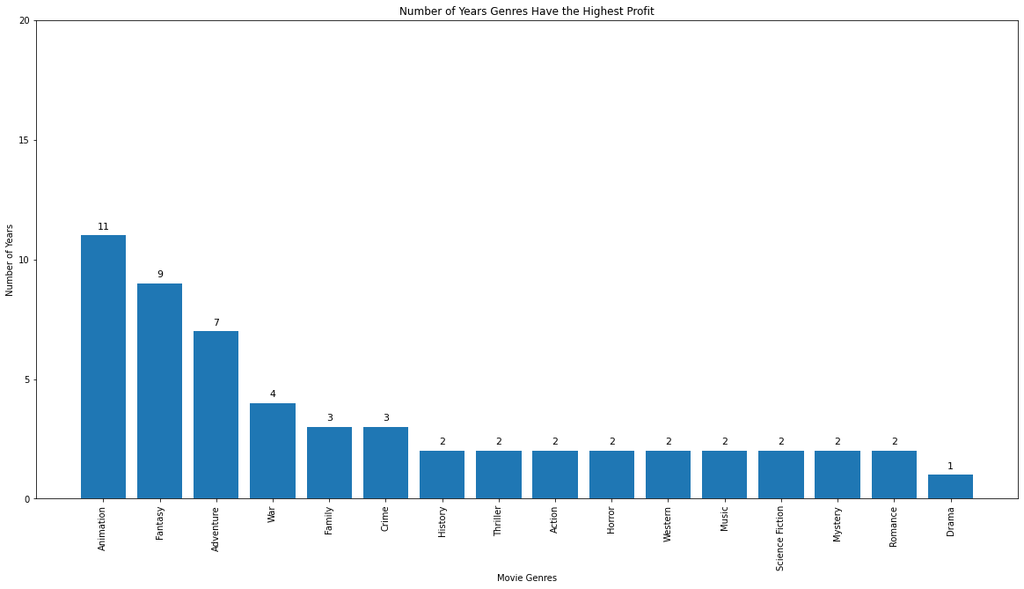

```python
profit_max = profit_mean.idxmax(axis = 1).value_counts()

plt.figure(figsize=(20, 10))
graph = plt.bar(profit_max.index, profit_max)

plt.title('Number of Years Genres Have the Highest Profit')
plt.xticks(rotation = 'vertical')
plt.yticks([0, 5, 10, 15, 20])
plt.xlabel('Movie Genres')
plt.ylabel('Number of Years')

# Place the values above the bars.
for p in graph.patches:
    plt.annotate(p.get_height(), (p.get_x() + p.get_width() / 2, p.get_height()), ha = 'center', va = 'center', fontsize = 11, xytext = (0, 10), textcoords = 'offset points')
plt.show()
```

This means that Animation genre is the highest profit genre over the years

### Research Question 2 : What kinds of properties are associated with movies that have high revenues?

```python
df.info()
```

```
<class 'pandas.core.frame.DataFrame'>
Int64Index: 3853 entries, 0 to 10848
Data columns (total 11 columns):
 #   Column          Non-Null Count  Dtype
---  ------          --------------  -----
 0   id              3853 non-null   int64
 1   budget          3853 non-null   int64
 2   revenue         3853 non-null   int64
 3   original_title  3853 non-null   object
 4   genres          3853 non-null   object
 5   vote_average    3853 non-null   float64
 6   release_year    3853 non-null   int64
 7   budget_adj      3853 non-null   float64
 8   revenue_adj     3853 non-null   float64
 9   newGenres       3853 non-null   object
 10  profit          3853 non-null   int64
dtypes: float64(3), int64(5), object(3)
memory usage: 490.3+ KB
```

```python
df.drop(['original_title', "revenue_adj", 'genres', 'newGenres'], axis=1).apply(lambda x: x.corr(df.revenue_adj))
```

```
id             -0.088293
budget          0.533435
revenue         0.900873
vote_average    0.267163
release_year   -0.103033
budget_adj      0.570390
profit          0.906407
dtype: float64
```

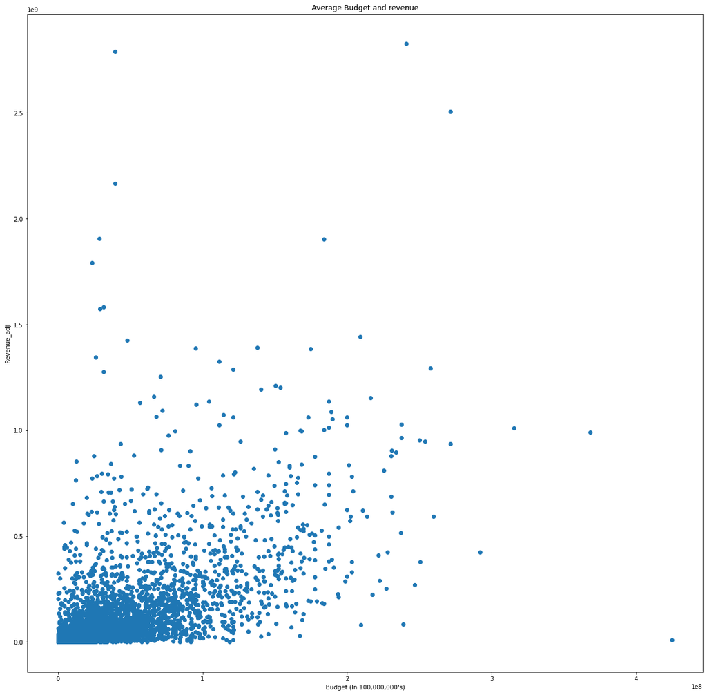

```python
plt.figure(figsize = (20, 20))
plt.title('Average Budget and revenue')
plt.xlabel("Budget (In 100,000,000's)")
plt.ylabel('Revenue_adj')
graph = plt.scatter(df['budget_adj'], df['revenue_adj'])

plt.show()
```

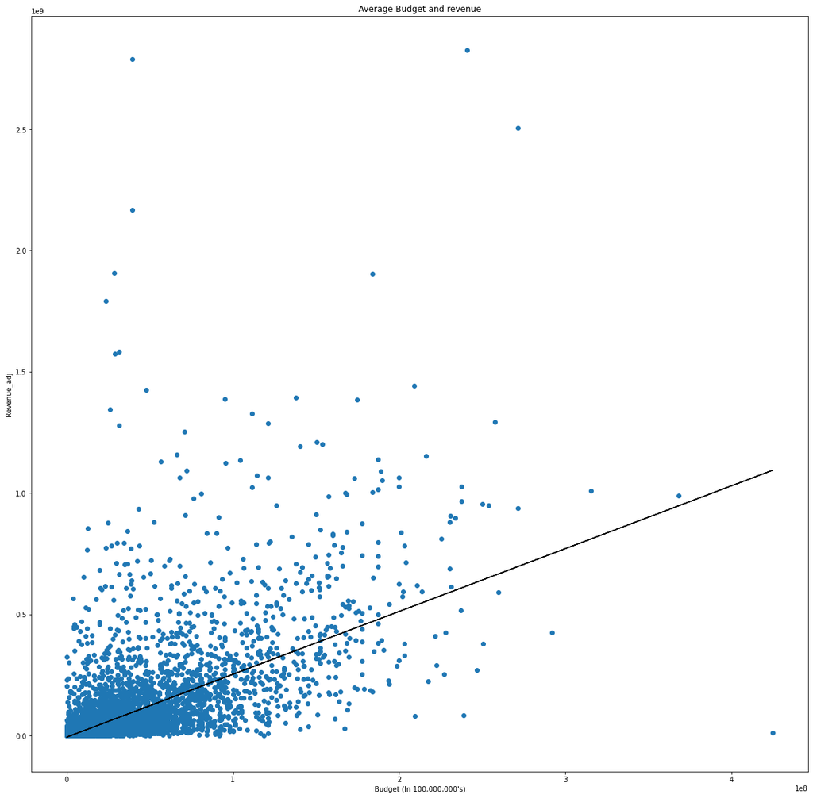

```python
plt.figure(figsize = (20, 20))
plt.title('Average Budget and revenue')
plt.xlabel("Budget (In 100,000,000's)")
plt.ylabel('Revenue_adj')
graph = plt.scatter(df['budget_adj'], df['revenue_adj'])

plt.plot(df['budget_adj'], np.poly1d(np.polyfit(df['budget_adj'], df['revenue'], 1))(df['budget_adj']), color = 'black')

plt.show()
```

## Conclusions

At this analysis of The Movie Dataset (TMDb) we determine the answers to these two questions. 1) Which genres are most popular from year to year?  
2) What kinds of properties are associated with movies that have high revenues?  
and many other question but we are focusing on these two main questions.

The most vote average movie genre by year varied as well, but the Documentary genre was the genre that had the highest vote average across the most years. This may be because documentaries are more serious productions that tend to be polished and because less of them are produced.

The most budget movie genre by year varied as well, but the History genre was the genre that had the highest badget across the most years. This may be because history movies materials and location costs too much to locks like old ones.

```python
from subprocess import call
call(['python', '-m', 'nbconvert', 'Investigate_a_Dataset.ipynb'])
```

```
1
```